# Financial Data Analysis with Python

```python
import pandas as pd
import numpy as np
import yfinance as yf
```

[output not shown]

```python
start = '2019-01-02'
end = '2025-06-21'
```

```python
symbol = 'BA'
```

```python
yf.download(symbol, start, end)
```

```
YF.download() has changed argument auto_adjust default to True
```

```
[*********************100%***********************]  1 of 1 completed
```

| Price Ticker Date | Close BA | High BA | Low BA | Open BA | Volume BA |
| --- | --- | --- | --- | --- | --- |
| 2019-01-02 | 314.645142 | 314.781193 | 304.830998 | 307.240817 | 3292200 |
| 2019-01-03 | 302.100555 | 310.690352 | 300.643010 | 310.447428 | 5705600 |
| 2019-01-04 | 317.822571 | 319.144094 | 307.133906 | 307.726657 | 4448800 |
| 2019-01-07 | 318.823425 | 321.330420 | 314.198169 | 321.165218 | 4030300 |
| 2019-01-08 | 330.891907 | 331.591530 | 323.234931 | 324.653600 | 4736500 |
| ... | ... | ... | ... | ... | ... |
| 2025-06-13 | 200.320007 | 202.229996 | 195.279999 | 200.679993 | 16093500 |
| 2025-06-16 | 201.699997 | 204.000000 | 199.080002 | 200.570007 | 6902700 |
| 2025-06-17 | 200.259995 | 205.309998 | 198.869995 | 201.309998 | 10844600 |
| 2025-06-18 | 197.679993 | 201.059998 | 196.800003 | 199.000000 | 7928300 |
| 2025-06-20 | 198.750000 | 200.679993 | 197.449997 | 198.660004 | 8934700 |

1626 rows × 5 columns

```python
df = yf.download(symbol, start, end)
df.tail()
```

```
[*********************100%***********************]  1 of 1 completed
```

| Price Ticker Date | Close BA | High BA | Low BA | Open BA | Volume BA |
| --- | --- | --- | --- | --- | --- |
| 2025-06-13 | 200.320007 | 202.229996 | 195.279999 | 200.679993 | 16093500 |
| 2025-06-16 | 201.699997 | 204.000000 | 199.080002 | 200.570007 | 6902700 |
| 2025-06-17 | 200.259995 | 205.309998 | 198.869995 | 201.309998 | 10844600 |
| 2025-06-18 | 197.679993 | 201.059998 | 196.800003 | 199.000000 | 7928300 |
| 2025-06-20 | 198.750000 | 200.679993 | 197.449997 | 198.660004 | 8934700 |

```python
df.info()
```

```
<class 'pandas.core.frame.DataFrame'>
DatetimeIndex: 1626 entries, 2019-01-02 to 2025-06-20
Data columns (total 5 columns):
 #   Column        Non-Null Count  Dtype
---  ------        --------------  -----
 0   (Close, BA)   1626 non-null   float64
 1   (High, BA)    1626 non-null   float64
 2   (Low, BA)     1626 non-null   float64
 3   (Open, BA)    1626 non-null   float64
 4   (Volume, BA)  1626 non-null   int64
dtypes: float64(4), int64(1)
memory usage: 76.2 KB
```

```python
symbol = ['JPY=X', 'BTC-USD', 'GC=F', 'EURUSD=X', '^DJI']
```

```python
df = yf.download(symbol, start, end)
df
```

```
[*********************100%***********************]  5 of 5 completed
```

| Price Ticker Date | Close BTC-USD | Close EURUSD=X | Close GC=F | Close JPY=X | Close ^DJI | High BTC-USD | High EURUSD=X | High GC=F | High JPY=X | High ^DJI | ... | Open BTC-USD | Open EURUSD=X | Open GC=F | Open JPY=X | Open ^DJI | Volume BTC-USD | Volume EURUSD=X | Volume GC=F | Volume JPY=X | Volume ^DJI |
| --- | --- | --- | --- | --- | --- | --- | --- | --- | --- | --- | --- | --- | --- | --- | --- | --- | --- | --- | --- | --- | --- |
| 2019-01-02 | 3943.409424 | 1.146171 | 1281.000000 | 109.667999 | 23346.240234 | 3947.981201 | 1.149700 | 1286.000000 | 109.674004 | 23413.470703 | ... | 3849.216309 | 1.146132 | 1286.000000 | 109.660004 | 23058.609375 | 5244856836 | 0.0 | 149.0 | 0.0 | 321570000.0 |
| 2019-01-03 | 3836.741211 | 1.131811 | 1291.800049 | 107.441002 | 22686.220703 | 3935.685059 | 1.140914 | 1292.000000 | 108.271004 | 23176.390625 | ... | 3931.048584 | 1.131734 | 1286.800049 | 107.449997 | 23176.390625 | 4530215219 | 0.0 | 10.0 | 0.0 | 424240000.0 |
| 2019-01-04 | 3857.717529 | 1.139108 | 1282.699951 | 107.807999 | 23433.160156 | 3865.934570 | 1.141774 | 1294.199951 | 108.583000 | 23518.640625 | ... | 3832.040039 | 1.139095 | 1294.199951 | 107.865997 | 22894.919922 | 4847965467 | 0.0 | 34.0 | 0.0 | 396020000.0 |
| 2019-01-05 | 3845.194580 | NaN | NaN | NaN | NaN | 3904.903076 | NaN | NaN | NaN | NaN | ... | 3851.973877 | NaN | NaN | NaN | NaN | 5137609824 | NaN | NaN | NaN | NaN |
| 2019-01-06 | 4076.632568 | NaN | NaN | NaN | NaN | 4093.297363 | NaN | NaN | NaN | NaN | ... | 3836.519043 | NaN | NaN | NaN | NaN | 5597027440 | NaN | NaN | NaN | NaN |
| ... | ... | ... | ... | ... | ... | ... | ... | ... | ... | ... | ... | ... | ... | ... | ... | ... | ... | ... | ... | ... | ... |
| 2025-06-16 | 106796.757812 | 1.155668 | 3396.399902 | 144.091003 | 42515.089844 | 108915.375000 | 1.161481 | 3442.000000 | 144.570999 | 42707.730469 | ... | 105555.593750 | 1.155668 | 3442.000000 | 144.091003 | 42300.128906 | 50366626945 | 0.0 | 480.0 | 0.0 | 467040000.0 |
| 2025-06-17 | 104601.117188 | 1.155135 | 3386.600098 | 144.729004 | 42215.800781 | 107750.195312 | 1.157407 | 3398.300049 | 145.263000 | 42530.828125 | ... | 106794.117188 | 1.155135 | 3398.300049 | 144.729004 | 42358.621094 | 55964092176 | 0.0 | 1477.0 | 0.0 | 423070000.0 |
| 2025-06-18 | 104883.328125 | 1.148264 | 3389.800049 | 145.376007 | 42171.660156 | 105581.851562 | 1.153004 | 3391.899902 | 145.438004 | 42510.070312 | ... | 104602.070312 | 1.148264 | 3385.300049 | 145.376007 | 42236.031250 | 47318089133 | 0.0 | 0.0 | 0.0 | 485440000.0 |
| 2025-06-19 | 104684.289062 | 1.147750 | NaN | 144.955002 | NaN | 105250.890625 | 1.148686 | NaN | 145.764999 | NaN | ... | 104886.773438 | 1.147750 | NaN | 144.955002 | NaN | 37333806920 | 0.0 | NaN | 0.0 | NaN |
| 2025-06-20 | 103309.601562 | 1.151278 | 3368.100098 | 145.218002 | 42206.820312 | 106539.382812 | 1.153456 | 3372.899902 | 145.953003 | 42432.191406 | ... | 104681.031250 | 1.151278 | 3350.000000 | 145.218002 | 42291.089844 | 50951862476 | 0.0 | 709.0 | 0.0 | 859840000.0 |

2362 rows × 25 columns

```python
df.info()
```

```
<class 'pandas.core.frame.DataFrame'>
DatetimeIndex: 2362 entries, 2019-01-02 to 2025-06-20
Freq: D
Data columns (total 25 columns):
 #   Column              Non-Null Count  Dtype
---  ------              --------------  -----
 0   (Close, BTC-USD)    2362 non-null   float64
 1   (Close, EURUSD=X)   1684 non-null   float64
 2   (Close, GC=F)       1627 non-null   float64
 3   (Close, JPY=X)      1684 non-null   float64
 4   (Close, ^DJI)       1626 non-null   float64
 5   (High, BTC-USD)     2362 non-null   float64
 6   (High, EURUSD=X)    1684 non-null   float64
 7   (High, GC=F)        1627 non-null   float64
 8   (High, JPY=X)       1684 non-null   float64
```

[output cut: 18 more lines]

```python
df.to_csv('multi_assets.csv')
```

# Initial Inspection and Visualization

```python
import pandas as pd
import matplotlib.pyplot as plt
pd.options.display.float_format = '{:.4}'.format
import seaborn as sns
sns.set()
```

```python
df = pd.read_csv('multi_assets.csv', header=[0,1], index_col=0, parse_dates=[0])
df
```

| Price Ticker Date | Close BTC-USD | Close EURUSD=X | Close GC=F | Close JPY=X | Close ^DJI | High BTC-USD | High EURUSD=X | High GC=F | High JPY=X | High ^DJI | ... | Open BTC-USD | Open EURUSD=X | Open GC=F | Open JPY=X | Open ^DJI | Volume BTC-USD | Volume EURUSD=X | Volume GC=F | Volume JPY=X | Volume ^DJI |
| --- | --- | --- | --- | --- | --- | --- | --- | --- | --- | --- | --- | --- | --- | --- | --- | --- | --- | --- | --- | --- | --- |
| 2019-01-02 | 3.943e+03 | 1.146 | 1.281e+03 | 109.7 | 2.335e+04 | 3.948e+03 | 1.15 | 1.286e+03 | 109.7 | 2.341e+04 | ... | 3.849e+03 | 1.146 | 1.286e+03 | 109.7 | 2.306e+04 | 5244856836 | 0.0 | 149.0 | 0.0 | 3.216e+08 |
| 2019-01-03 | 3.837e+03 | 1.132 | 1.292e+03 | 107.4 | 2.269e+04 | 3.936e+03 | 1.141 | 1.292e+03 | 108.3 | 2.318e+04 | ... | 3.931e+03 | 1.132 | 1.287e+03 | 107.4 | 2.318e+04 | 4530215219 | 0.0 | 10.0 | 0.0 | 4.242e+08 |
| 2019-01-04 | 3.858e+03 | 1.139 | 1.283e+03 | 107.8 | 2.343e+04 | 3.866e+03 | 1.142 | 1.294e+03 | 108.6 | 2.352e+04 | ... | 3.832e+03 | 1.139 | 1.294e+03 | 107.9 | 2.289e+04 | 4847965467 | 0.0 | 34.0 | 0.0 | 3.96e+08 |
| 2019-01-05 | 3.845e+03 | NaN | NaN | NaN | NaN | 3.905e+03 | NaN | NaN | NaN | NaN | ... | 3.852e+03 | NaN | NaN | NaN | NaN | 5137609824 | NaN | NaN | NaN | NaN |
| 2019-01-06 | 4.077e+03 | NaN | NaN | NaN | NaN | 4.093e+03 | NaN | NaN | NaN | NaN | ... | 3.837e+03 | NaN | NaN | NaN | NaN | 5597027440 | NaN | NaN | NaN | NaN |
| ... | ... | ... | ... | ... | ... | ... | ... | ... | ... | ... | ... | ... | ... | ... | ... | ... | ... | ... | ... | ... | ... |
| 2025-06-16 | 1.068e+05 | 1.156 | 3.396e+03 | 144.1 | 4.252e+04 | 1.089e+05 | 1.161 | 3.442e+03 | 144.6 | 4.271e+04 | ... | 1.056e+05 | 1.156 | 3.442e+03 | 144.1 | 4.23e+04 | 50366626945 | 0.0 | 480.0 | 0.0 | 4.67e+08 |
| 2025-06-17 | 1.046e+05 | 1.155 | 3.387e+03 | 144.7 | 4.222e+04 | 1.078e+05 | 1.157 | 3.398e+03 | 145.3 | 4.253e+04 | ... | 1.068e+05 | 1.155 | 3.398e+03 | 144.7 | 4.236e+04 | 55964092176 | 0.0 | 1.477e+03 | 0.0 | 4.231e+08 |
| 2025-06-18 | 1.049e+05 | 1.148 | 3.39e+03 | 145.4 | 4.217e+04 | 1.056e+05 | 1.153 | 3.392e+03 | 145.4 | 4.251e+04 | ... | 1.046e+05 | 1.148 | 3.385e+03 | 145.4 | 4.224e+04 | 47318089133 | 0.0 | 0.0 | 0.0 | 4.854e+08 |
| 2025-06-19 | 1.047e+05 | 1.148 | NaN | 145.0 | NaN | 1.053e+05 | 1.149 | NaN | 145.8 | NaN | ... | 1.049e+05 | 1.148 | NaN | 145.0 | NaN | 37333806920 | 0.0 | NaN | 0.0 | NaN |
| 2025-06-20 | 1.033e+05 | 1.151 | 3.368e+03 | 145.2 | 4.221e+04 | 1.065e+05 | 1.153 | 3.373e+03 | 146.0 | 4.243e+04 | ... | 1.047e+05 | 1.151 | 3.35e+03 | 145.2 | 4.229e+04 | 50951862476 | 0.0 | 709.0 | 0.0 | 8.598e+08 |

2362 rows × 25 columns

```python
df.info()
```

```
<class 'pandas.core.frame.DataFrame'>
DatetimeIndex: 2362 entries, 2019-01-02 to 2025-06-20
Data columns (total 25 columns):
 #   Column              Non-Null Count  Dtype
---  ------              --------------  -----
 0   (Close, BTC-USD)    2362 non-null   float64
 1   (Close, EURUSD=X)   1684 non-null   float64
 2   (Close, GC=F)       1627 non-null   float64
 3   (Close, JPY=X)      1684 non-null   float64
 4   (Close, ^DJI)       1626 non-null   float64
 5   (High, BTC-USD)     2362 non-null   float64
 6   (High, EURUSD=X)    1684 non-null   float64
 7   (High, GC=F)        1627 non-null   float64
 8   (High, JPY=X)       1684 non-null   float64
 9   (High, ^DJI)        1626 non-null   float64
```

[output cut: 17 more lines]

```python
df.Close
```

| Ticker Date | BTC-USD | EURUSD=X | GC=F | JPY=X | ^DJI |
| --- | --- | --- | --- | --- | --- |
| 2019-01-02 | 3.943e+03 | 1.146 | 1.281e+03 | 109.7 | 2.335e+04 |
| 2019-01-03 | 3.837e+03 | 1.132 | 1.292e+03 | 107.4 | 2.269e+04 |
| 2019-01-04 | 3.858e+03 | 1.139 | 1.283e+03 | 107.8 | 2.343e+04 |
| 2019-01-05 | 3.845e+03 | NaN | NaN | NaN | NaN |
| 2019-01-06 | 4.077e+03 | NaN | NaN | NaN | NaN |
| ... | ... | ... | ... | ... | ... |
| 2025-06-16 | 1.068e+05 | 1.156 | 3.396e+03 | 144.1 | 4.252e+04 |
| 2025-06-17 | 1.046e+05 | 1.155 | 3.387e+03 | 144.7 | 4.222e+04 |
| 2025-06-18 | 1.049e+05 | 1.148 | 3.39e+03 | 145.4 | 4.217e+04 |
| 2025-06-19 | 1.047e+05 | 1.148 | NaN | 145.0 | NaN |
| 2025-06-20 | 1.033e+05 | 1.151 | 3.368e+03 | 145.2 | 4.221e+04 |

2362 rows × 5 columns

```python
df.Close['^DJI']
```

```
Date
2019-01-02   2.335e+04
2019-01-03   2.269e+04
2019-01-04   2.343e+04
2019-01-05         NaN
2019-01-06         NaN
                ...
2025-06-16   4.252e+04
2025-06-17   4.222e+04
2025-06-18   4.217e+04
2025-06-19         NaN
2025-06-20   4.221e+04
Name: ^DJI, Length: 2362, dtype: float64
```

```python
df.loc['2020-08-10']
```

```
Price   Ticker
Close   BTC-USD    1.188e+04
        EURUSD=X       1.178
        GC=F       2.024e+03
        JPY=X          105.8
        ^DJI       2.779e+04
High    BTC-USD    1.205e+04
        EURUSD=X        1.18
        GC=F       2.044e+03
        JPY=X          106.2
        ^DJI        2.78e+04
Low     BTC-USD    1.166e+04
        EURUSD=X       1.174
        GC=F       2.018e+03
        JPY=X          105.7
        ^DJI       2.749e+04
Open    BTC-USD    1.166e+04
        EURUSD=X       1.178
        GC=F       2.026e+03
        JPY=X          105.9
        ^DJI       2.749e+04
Volume  BTC-USD    2.611e+10
        EURUSD=X         0.0
        GC=F           233.0
        JPY=X            0.0
        ^DJI       3.603e+08
Name: 2020-08-10 00:00:00, dtype: float64
```

```python
df.loc['2020']
```

| Price Ticker Date | Close BTC-USD | Close EURUSD=X | Close GC=F | Close JPY=X | Close ^DJI | High BTC-USD | High EURUSD=X | High GC=F | High JPY=X | High ^DJI | ... | Open BTC-USD | Open EURUSD=X | Open GC=F | Open JPY=X | Open ^DJI | Volume BTC-USD | Volume EURUSD=X | Volume GC=F | Volume JPY=X | Volume ^DJI |
| --- | --- | --- | --- | --- | --- | --- | --- | --- | --- | --- | --- | --- | --- | --- | --- | --- | --- | --- | --- | --- | --- |
| 2020-01-01 | 7.2e+03 | 1.122 | NaN | 108.7 | NaN | 7.254e+03 | 1.123 | NaN | 111.4 | NaN | ... | 7.195e+03 | 1.122 | NaN | 108.7 | NaN | 18565664997 | 0.0 | NaN | 0.0 | NaN |
| 2020-01-02 | 6.985e+03 | 1.122 | 1.524e+03 | 108.7 | 2.887e+04 | 7.212e+03 | 1.123 | 1.529e+03 | 108.9 | 2.887e+04 | ... | 7.203e+03 | 1.122 | 1.518e+03 | 108.7 | 2.864e+04 | 20802083465 | 0.0 | 214.0 | 0.0 | 2.518e+08 |
| 2020-01-03 | 7.345e+03 | 1.117 | 1.549e+03 | 108.5 | 2.863e+04 | 7.414e+03 | 1.118 | 1.553e+03 | 108.6 | 2.872e+04 | ... | 6.984e+03 | 1.117 | 1.53e+03 | 108.5 | 2.855e+04 | 28111481032 | 0.0 | 107.0 | 0.0 | 2.396e+08 |
| 2020-01-04 | 7.411e+03 | NaN | NaN | NaN | NaN | 7.427e+03 | NaN | NaN | NaN | NaN | ... | 7.345e+03 | NaN | NaN | NaN | NaN | 18444271275 | NaN | NaN | NaN | NaN |
| 2020-01-05 | 7.411e+03 | NaN | NaN | NaN | NaN | 7.544e+03 | NaN | NaN | NaN | NaN | ... | 7.41e+03 | NaN | NaN | NaN | NaN | 19725074095 | NaN | NaN | NaN | NaN |
| ... | ... | ... | ... | ... | ... | ... | ... | ... | ... | ... | ... | ... | ... | ... | ... | ... | ... | ... | ... | ... | ... |
| 2020-12-27 | 2.627e+04 | NaN | NaN | NaN | NaN | 2.829e+04 | NaN | NaN | NaN | NaN | ... | 2.644e+04 | NaN | NaN | NaN | NaN | 66479895605 | NaN | NaN | NaN | NaN |
| 2020-12-28 | 2.708e+04 | 1.221 | 1.877e+03 | 103.5 | 3.04e+04 | 2.739e+04 | 1.225 | 1.896e+03 | 103.9 | 3.053e+04 | ... | 2.628e+04 | 1.221 | 1.896e+03 | 103.5 | 3.028e+04 | 49056742893 | 0.0 | 75.0 | 0.0 | 3.025e+08 |
| 2020-12-29 | 2.736e+04 | 1.222 | 1.88e+03 | 103.7 | 3.034e+04 | 2.737e+04 | 1.228 | 1.881e+03 | 103.8 | 3.059e+04 | ... | 2.708e+04 | 1.222 | 1.881e+03 | 103.7 | 3.049e+04 | 45265946774 | 0.0 | 343.0 | 0.0 | 3.576e+08 |
| 2020-12-30 | 2.884e+04 | 1.225 | 1.891e+03 | 103.6 | 3.041e+04 | 2.894e+04 | 1.231 | 1.896e+03 | 103.6 | 3.053e+04 | ... | 2.736e+04 | 1.225 | 1.88e+03 | 103.6 | 3.042e+04 | 51287442704 | 0.0 | 444.0 | 0.0 | 2.919e+08 |
| 2020-12-31 | 2.9e+04 | 1.23 | 1.893e+03 | 103.1 | 3.061e+04 | 2.924e+04 | 1.231 | 1.901e+03 | 103.3 | 3.064e+04 | ... | 2.884e+04 | 1.23 | 1.897e+03 | 103.1 | 3.042e+04 | 46754964848 | 0.0 | 127.0 | 0.0 | 2.845e+08 |

366 rows × 25 columns

```python
df.loc['2020-06', ('Close', 'BTC-USD')]
```

```
Date
2020-06-01   1.017e+04
2020-06-02    9.53e+03
2020-06-03   9.657e+03
2020-06-04   9.801e+03
2020-06-05   9.666e+03
2020-06-06   9.654e+03
2020-06-07   9.759e+03
2020-06-08   9.771e+03
2020-06-09   9.796e+03
2020-06-10    9.87e+03
2020-06-11   9.322e+03
2020-06-12   9.481e+03
2020-06-13   9.475e+03
2020-06-14   9.387e+03
2020-06-15   9.451e+03
2020-06-16   9.538e+03
2020-06-17    9.48e+03
2020-06-18   9.412e+03
2020-06-19   9.288e+03
2020-06-20   9.332e+03
2020-06-21   9.304e+03
2020-06-22   9.649e+03
2020-06-23    9.63e+03
2020-06-24   9.314e+03
2020-06-25   9.265e+03
2020-06-26   9.163e+03
2020-06-27   9.045e+03
2020-06-28   9.144e+03
2020-06-29   9.191e+03
2020-06-30   9.138e+03
Name: (Close, BTC-USD), dtype: float64
```

```python
close = df.Close.copy()
close
```

| Ticker Date | BTC-USD | EURUSD=X | GC=F | JPY=X | ^DJI |
| --- | --- | --- | --- | --- | --- |
| 2019-01-02 | 3.943e+03 | 1.146 | 1.281e+03 | 109.7 | 2.335e+04 |
| 2019-01-03 | 3.837e+03 | 1.132 | 1.292e+03 | 107.4 | 2.269e+04 |
| 2019-01-04 | 3.858e+03 | 1.139 | 1.283e+03 | 107.8 | 2.343e+04 |
| 2019-01-05 | 3.845e+03 | NaN | NaN | NaN | NaN |
| 2019-01-06 | 4.077e+03 | NaN | NaN | NaN | NaN |
| ... | ... | ... | ... | ... | ... |
| 2025-06-16 | 1.068e+05 | 1.156 | 3.396e+03 | 144.1 | 4.252e+04 |
| 2025-06-17 | 1.046e+05 | 1.155 | 3.387e+03 | 144.7 | 4.222e+04 |
| 2025-06-18 | 1.049e+05 | 1.148 | 3.39e+03 | 145.4 | 4.217e+04 |
| 2025-06-19 | 1.047e+05 | 1.148 | NaN | 145.0 | NaN |
| 2025-06-20 | 1.033e+05 | 1.151 | 3.368e+03 | 145.2 | 4.221e+04 |

2362 rows × 5 columns

```python
close.describe()
```

| Ticker | BTC-USD | EURUSD=X | GC=F | JPY=X | ^DJI |
| --- | --- | --- | --- | --- | --- |
| count | 2.362e+03 | 1.684e+03 | 1.627e+03 | 1.684e+03 | 1.626e+03 |
| mean | 3.615e+04 | 1.109 | 1.937e+03 | 126.5 | 3.314e+04 |
| std | 2.71e+04 | 0.05325 | 444.2 | 18.69 | 5.524e+03 |
| min | 3.399e+03 | 0.9596 | 1.269e+03 | 102.7 | 1.859e+04 |
| 25% | 1.113e+04 | 1.078 | 1.719e+03 | 108.9 | 2.83e+04 |
| 50% | 2.93e+04 | 1.102 | 1.846e+03 | 121.9 | 3.36e+04 |
| 75% | 5.419e+04 | 1.137 | 2.006e+03 | 145.0 | 3.61e+04 |
| max | 1.117e+05 | 1.234 | 3.431e+03 | 161.6 | 4.501e+04 |

```python
close.info()
```

[output not shown]

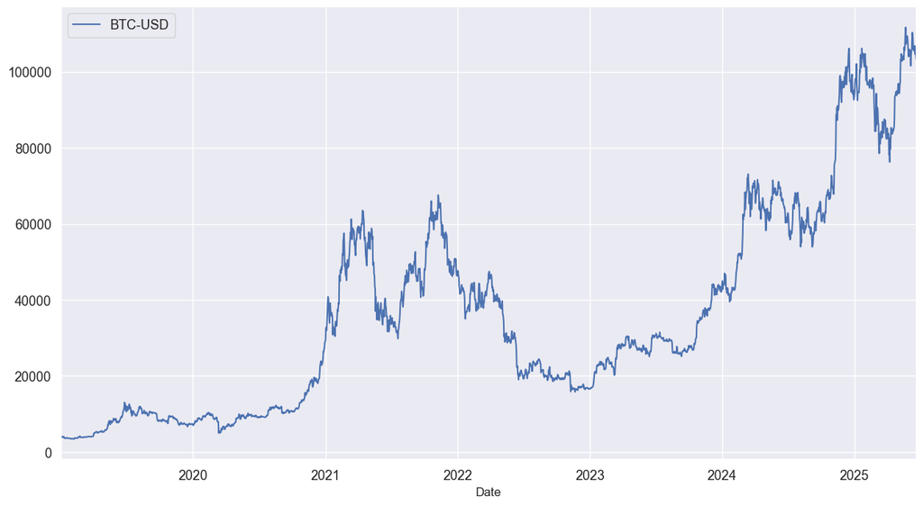

```python
close['BTC-USD'].dropna().plot(figsize = (15,8), fontsize = 13)
plt.legend(fontsize = 13)
plt.show()
```

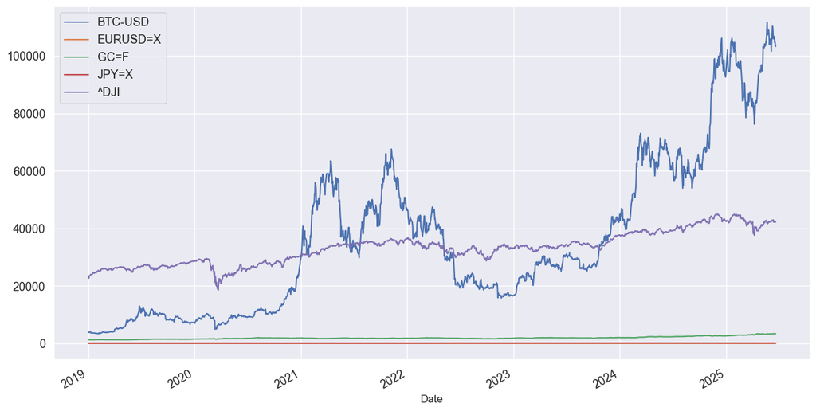

```python
close.dropna().plot(figsize = (15,8), fontsize = 13)
plt.legend(fontsize = 13)
plt.show()
```

# Normalizing Financial Time Series to a Base Value (100)

```python
close
```

| Ticker Date | BTC-USD | EURUSD=X | GC=F | JPY=X | ^DJI |
| --- | --- | --- | --- | --- | --- |
| 2019-01-02 | 3.943e+03 | 1.146 | 1.281e+03 | 109.7 | 2.335e+04 |
| 2019-01-03 | 3.837e+03 | 1.132 | 1.292e+03 | 107.4 | 2.269e+04 |
| 2019-01-04 | 3.858e+03 | 1.139 | 1.283e+03 | 107.8 | 2.343e+04 |
| 2019-01-05 | 3.845e+03 | NaN | NaN | NaN | NaN |
| 2019-01-06 | 4.077e+03 | NaN | NaN | NaN | NaN |
| ... | ... | ... | ... | ... | ... |
| 2025-06-16 | 1.068e+05 | 1.156 | 3.396e+03 | 144.1 | 4.252e+04 |
| 2025-06-17 | 1.046e+05 | 1.155 | 3.387e+03 | 144.7 | 4.222e+04 |
| 2025-06-18 | 1.049e+05 | 1.148 | 3.39e+03 | 145.4 | 4.217e+04 |
| 2025-06-19 | 1.047e+05 | 1.148 | NaN | 145.0 | NaN |
| 2025-06-20 | 1.033e+05 | 1.151 | 3.368e+03 | 145.2 | 4.221e+04 |

2362 rows × 5 columns

```python
close.iloc[0]
```

```
Ticker
BTC-USD    3.943e+03
EURUSD=X       1.146
GC=F       1.281e+03
JPY=X          109.7
^DJI       2.335e+04
Name: 2019-01-02 00:00:00, dtype: float64
```

```python
norm = close.div(close.iloc[0]).mul(100) # bagi dengan angka pertama dari time series lalu kalikan dengan 100
norm
```

| Ticker Date | BTC-USD | EURUSD=X | GC=F | JPY=X | ^DJI |
| --- | --- | --- | --- | --- | --- |
| 2019-01-02 | 100.0 | 100.0 | 100.0 | 100.0 | 100.0 |
| 2019-01-03 | 97.3 | 98.75 | 100.8 | 97.97 | 97.17 |
| 2019-01-04 | 97.83 | 99.38 | 100.1 | 98.3 | 100.4 |
| 2019-01-05 | 97.51 | NaN | NaN | NaN | NaN |
| 2019-01-06 | 103.4 | NaN | NaN | NaN | NaN |
| ... | ... | ... | ... | ... | ... |
| 2025-06-16 | 2.708e+03 | 100.8 | 265.1 | 131.4 | 182.1 |
| 2025-06-17 | 2.653e+03 | 100.8 | 264.4 | 132.0 | 180.8 |
| 2025-06-18 | 2.66e+03 | 100.2 | 264.6 | 132.6 | 180.6 |
| 2025-06-19 | 2.655e+03 | 100.1 | NaN | 132.2 | NaN |
| 2025-06-20 | 2.62e+03 | 100.4 | 262.9 | 132.4 | 180.8 |

2362 rows × 5 columns

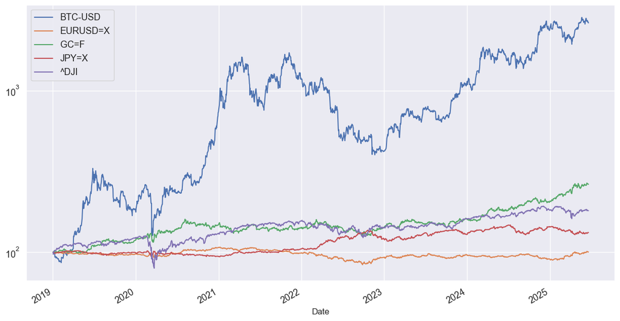

```python
norm.dropna().plot(figsize = (15,8), fontsize =13, logy = True)
plt.legend(fontsize = 13)
plt.show()
```

```python
close.to_csv('close.csv')
```

# Price Changes and Financial Returns

more meaningful/useful than Prices: Price Changes

```python
close = pd.read_csv('close.csv', index_col = 'Date', parse_dates=['Date'])
close
```

| Date | BTC-USD | EURUSD=X | GC=F | JPY=X | ^DJI |
| --- | --- | --- | --- | --- | --- |
| 2019-01-02 | 3.943e+03 | 1.146 | 1.281e+03 | 109.7 | 2.335e+04 |
| 2019-01-03 | 3.837e+03 | 1.132 | 1.292e+03 | 107.4 | 2.269e+04 |
| 2019-01-04 | 3.858e+03 | 1.139 | 1.283e+03 | 107.8 | 2.343e+04 |
| 2019-01-05 | 3.845e+03 | NaN | NaN | NaN | NaN |
| 2019-01-06 | 4.077e+03 | NaN | NaN | NaN | NaN |
| ... | ... | ... | ... | ... | ... |
| 2025-06-16 | 1.068e+05 | 1.156 | 3.396e+03 | 144.1 | 4.252e+04 |
| 2025-06-17 | 1.046e+05 | 1.155 | 3.387e+03 | 144.7 | 4.222e+04 |
| 2025-06-18 | 1.049e+05 | 1.148 | 3.39e+03 | 145.4 | 4.217e+04 |
| 2025-06-19 | 1.047e+05 | 1.148 | NaN | 145.0 | NaN |
| 2025-06-20 | 1.033e+05 | 1.151 | 3.368e+03 | 145.2 | 4.221e+04 |

2362 rows × 5 columns

```python
usdjpy = close['JPY=X'].dropna().to_frame().copy()
```

```python
usdjpy
```

| Date | JPY=X |
| --- | --- |
| 2019-01-02 | 109.7 |
| 2019-01-03 | 107.4 |
| 2019-01-04 | 107.8 |
| 2019-01-07 | 108.5 |
| 2019-01-08 | 108.6 |
| ... | ... |
| 2025-06-16 | 144.1 |
| 2025-06-17 | 144.7 |
| 2025-06-18 | 145.4 |
| 2025-06-19 | 145.0 |
| 2025-06-20 | 145.2 |

1684 rows × 1 columns

```python
usdjpy.rename(columns={'JPY=X' :'Price'}, inplace = True)
usdjpy
```

| Date | Price |
| --- | --- |
| 2019-01-02 | 109.7 |
| 2019-01-03 | 107.4 |
| 2019-01-04 | 107.8 |
| 2019-01-07 | 108.5 |
| 2019-01-08 | 108.6 |
| ... | ... |
| 2025-06-16 | 144.1 |
| 2025-06-17 | 144.7 |
| 2025-06-18 | 145.4 |
| 2025-06-19 | 145.0 |
| 2025-06-20 | 145.2 |

1684 rows × 1 columns

```python
usdjpy.shift(periods=1)
```

| Date | Price |
| --- | --- |
| 2019-01-02 | NaN |
| 2019-01-03 | 109.7 |
| 2019-01-04 | 107.4 |
| 2019-01-07 | 107.8 |
| 2019-01-08 | 108.5 |
| ... | ... |
| 2025-06-16 | 143.2 |
| 2025-06-17 | 144.1 |
| 2025-06-18 | 144.7 |
| 2025-06-19 | 145.4 |
| 2025-06-20 | 145.0 |

1684 rows × 1 columns

```python
usdjpy['P_lag1'] = usdjpy.shift(periods=1)
usdjpy
```

| Date | Price | P_lag1 |
| --- | --- | --- |
| 2019-01-02 | 109.7 | NaN |
| 2019-01-03 | 107.4 | 109.7 |
| 2019-01-04 | 107.8 | 107.4 |
| 2019-01-07 | 108.5 | 107.8 |
| 2019-01-08 | 108.6 | 108.5 |
| ... | ... | ... |
| 2025-06-16 | 144.1 | 143.2 |
| 2025-06-17 | 144.7 | 144.1 |
| 2025-06-18 | 145.4 | 144.7 |
| 2025-06-19 | 145.0 | 145.4 |
| 2025-06-20 | 145.2 | 145.0 |

1684 rows × 2 columns

Absolute Price Changes (Differece)

```python
usdjpy['P_diff'] = usdjpy.Price.sub(usdjpy.P_lag1)# one method
usdjpy
```

| Date | Price | P_lag1 | P_diff |
| --- | --- | --- | --- |
| 2019-01-02 | 109.7 | NaN | NaN |
| 2019-01-03 | 107.4 | 109.7 | -2.227 |
| 2019-01-04 | 107.8 | 107.4 | 0.367 |
| 2019-01-07 | 108.5 | 107.8 | 0.714 |
| 2019-01-08 | 108.6 | 108.5 | 0.09399 |
| ... | ... | ... | ... |
| 2025-06-16 | 144.1 | 143.2 | 0.897 |
| 2025-06-17 | 144.7 | 144.1 | 0.638 |
| 2025-06-18 | 145.4 | 144.7 | 0.647 |
| 2025-06-19 | 145.0 | 145.4 | -0.421 |
| 2025-06-20 | 145.2 | 145.0 | 0.263 |

1684 rows × 3 columns

```python
usdjpy['P_diff2'] = usdjpy.Price.diff(periods = 1) # other method
usdjpy
```

| Date | Price | P_lag1 | P_diff | P_diff2 |
| --- | --- | --- | --- | --- |
| 2019-01-02 | 109.7 | NaN | NaN | NaN |
| 2019-01-03 | 107.4 | 109.7 | -2.227 | -2.227 |
| 2019-01-04 | 107.8 | 107.4 | 0.367 | 0.367 |
| 2019-01-07 | 108.5 | 107.8 | 0.714 | 0.714 |
| 2019-01-08 | 108.6 | 108.5 | 0.09399 | 0.09399 |
| ... | ... | ... | ... | ... |
| 2025-06-16 | 144.1 | 143.2 | 0.897 | 0.897 |
| 2025-06-17 | 144.7 | 144.1 | 0.638 | 0.638 |
| 2025-06-18 | 145.4 | 144.7 | 0.647 | 0.647 |
| 2025-06-19 | 145.0 | 145.4 | -0.421 | -0.421 |
| 2025-06-20 | 145.2 | 145.0 | 0.263 | 0.263 |

1684 rows × 4 columns

Absolute Price Change are not meaningful  
Relative/Percentage Price Changes (Returns)

```python
usdjpy.Price.div(usdjpy.P_lag1) - 1 # one method
```

```
Date
2019-01-02         NaN
2019-01-03    -0.02031
2019-01-04    0.003416
2019-01-07    0.006623
2019-01-08   0.0008661
                ...
2025-06-16    0.006264
2025-06-17    0.004428
2025-06-18     0.00447
2025-06-19   -0.002896
2025-06-20    0.001814
Length: 1684, dtype: float64
```

```python
usdjpy['Returns'] = usdjpy.Price.pct_change(periods = 1) #other method
usdjpy
```

| Date | Price | P_lag1 | P_diff | P_diff2 | Returns |
| --- | --- | --- | --- | --- | --- |
| 2019-01-02 | 109.7 | NaN | NaN | NaN | NaN |
| 2019-01-03 | 107.4 | 109.7 | -2.227 | -2.227 | -0.02031 |
| 2019-01-04 | 107.8 | 107.4 | 0.367 | 0.367 | 0.003416 |
| 2019-01-07 | 108.5 | 107.8 | 0.714 | 0.714 | 0.006623 |
| 2019-01-08 | 108.6 | 108.5 | 0.09399 | 0.09399 | 0.0008661 |
| ... | ... | ... | ... | ... | ... |
| 2025-06-16 | 144.1 | 143.2 | 0.897 | 0.897 | 0.006264 |
| 2025-06-17 | 144.7 | 144.1 | 0.638 | 0.638 | 0.004428 |
| 2025-06-18 | 145.4 | 144.7 | 0.647 | 0.647 | 0.00447 |
| 2025-06-19 | 145.0 | 145.4 | -0.421 | -0.421 | -0.002896 |
| 2025-06-20 | 145.2 | 145.0 | 0.263 | 0.263 | 0.001814 |

1684 rows × 5 columns

Relative Price Changes (Returns) are meaningfull and comparable across instruments  
for example, 20% price change increase has the same meaning across all instrument

```python
usdjpy.drop(columns=['P_lag1', 'P_diff', 'P_diff2'], inplace = True)
usdjpy
```

| Date | Price | Returns |
| --- | --- | --- |
| 2019-01-02 | 109.7 | NaN |
| 2019-01-03 | 107.4 | -0.02031 |
| 2019-01-04 | 107.8 | 0.003416 |
| 2019-01-07 | 108.5 | 0.006623 |
| 2019-01-08 | 108.6 | 0.0008661 |
| ... | ... | ... |
| 2025-06-16 | 144.1 | 0.006264 |
| 2025-06-17 | 144.7 | 0.004428 |
| 2025-06-18 | 145.4 | 0.00447 |
| 2025-06-19 | 145.0 | -0.002896 |
| 2025-06-20 | 145.2 | 0.001814 |

1684 rows × 2 columns

```python
usdjpy.to_csv('usdjpy.csv')
```

# Measuring Reward and Risk of an investment

```python
usdjpy = pd.read_csv('usdjpy.csv', index_col='Date', parse_dates=['Date'])
usdjpy
```

| Date | Price | Returns |
| --- | --- | --- |
| 2019-01-02 | 109.7 | NaN |
| 2019-01-03 | 107.4 | -0.02031 |
| 2019-01-04 | 107.8 | 0.003416 |
| 2019-01-07 | 108.5 | 0.006623 |
| 2019-01-08 | 108.6 | 0.0008661 |
| ... | ... | ... |
| 2025-06-16 | 144.1 | 0.006264 |
| 2025-06-17 | 144.7 | 0.004428 |
| 2025-06-18 | 145.4 | 0.00447 |
| 2025-06-19 | 145.0 | -0.002896 |
| 2025-06-20 | 145.2 | 0.001814 |

1684 rows × 2 columns

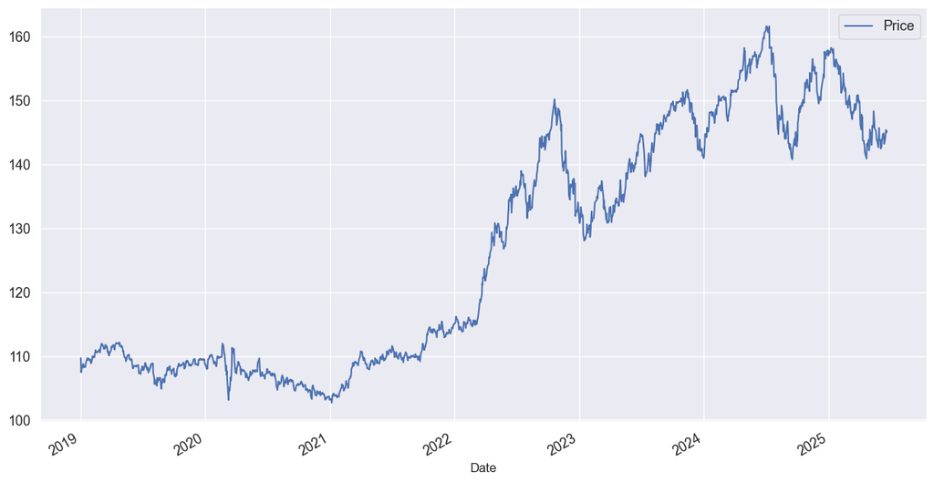

```python
usdjpy.Price.plot(figsize = (15,8), fontsize = 13)
plt.legend(fontsize = 13)
plt.show()
```

Reward: Positive Returns  
Risk: Volatility of Returns

```python
usdjpy.describe()
```

|  | Price | Returns |
| --- | --- | --- |
| count | 1.684e+03 | 1.683e+03 |
| mean | 126.5 | 0.0001829 |
| std | 18.69 | 0.005666 |
| min | 102.7 | -0.03725 |
| 25% | 108.9 | -0.0025 |
| 50% | 121.9 | 0.0003825 |
| 75% | 145.0 | 0.00313 |
| max | 161.6 | 0.02705 |

```python
mu = usdjpy.Returns.mean() #arithmetic mean return -> Reward
mu
```

```
0.000182908874089436
```

```python
sigma = usdjpy.Returns.std() #std of returns -> Risk/Volatility
sigma
```

```
0.005666469210889783
```

# Comparing BTC-USD TO ^DJI

```python
btc = pd.DataFrame()
btc['Price'] = close['BTC-USD']

dji = pd.DataFrame()
dji['Price'] = close['^DJI']
```

```python
btc
```

| Date | Price |
| --- | --- |
| 2019-01-02 | 3.943e+03 |
| 2019-01-03 | 3.837e+03 |
| 2019-01-04 | 3.858e+03 |
| 2019-01-05 | 3.845e+03 |
| 2019-01-06 | 4.077e+03 |
| ... | ... |
| 2025-06-16 | 1.068e+05 |
| 2025-06-17 | 1.046e+05 |
| 2025-06-18 | 1.049e+05 |
| 2025-06-19 | 1.047e+05 |
| 2025-06-20 | 1.033e+05 |

2362 rows × 1 columns

```python
btc['Returns'] = btc.Price.pct_change(periods = 1, fill_method=None)
dji['Returns'] = dji.Price.pct_change(periods = 1, fill_method=None)
```

```python
btc.describe()
```

|  | Price | Returns |
| --- | --- | --- |
| count | 2.362e+03 | 2.361e+03 |
| mean | 3.615e+04 | 0.001947 |
| std | 2.71e+04 | 0.03333 |
| min | 3.399e+03 | -0.3717 |
| 25% | 1.113e+04 | -0.01278 |
| 50% | 2.93e+04 | 0.0007549 |
| 75% | 5.419e+04 | 0.01594 |
| max | 1.117e+05 | 0.1875 |

```python
dji.describe()
```

|  | Price | Returns |
| --- | --- | --- |
| count | 1.626e+03 | 1.272e+03 |
| mean | 3.314e+04 | 0.0005323 |
| std | 5.524e+03 | 0.01213 |
| min | 1.859e+04 | -0.09988 |
| 25% | 2.83e+04 | -0.004516 |
| 50% | 3.36e+04 | 0.0007067 |
| 75% | 3.61e+04 | 0.006108 |
| max | 4.501e+04 | 0.1137 |

Higher Risk -> Higher Reward rule does apply

# Investment Multiple and CAGR

Two alternative reward metrics that are more intuitive and easier to interpret.

```python
usdjpy = pd.read_csv('usdjpy.csv', index_col="Date", parse_dates=['Date'])
usdjpy
```

| Date | Price | Returns |
| --- | --- | --- |
| 2019-01-02 | 109.7 | NaN |
| 2019-01-03 | 107.4 | -0.02031 |
| 2019-01-04 | 107.8 | 0.003416 |
| 2019-01-07 | 108.5 | 0.006623 |
| 2019-01-08 | 108.6 | 0.0008661 |
| ... | ... | ... |
| 2025-06-16 | 144.1 | 0.006264 |
| 2025-06-17 | 144.7 | 0.004428 |
| 2025-06-18 | 145.4 | 0.00447 |
| 2025-06-19 | 145.0 | -0.002896 |
| 2025-06-20 | 145.2 | 0.001814 |

1684 rows × 2 columns

Investment Multiple: Ending Value of 1 [Dollar] invested.  
Multiple = Ending Value / Initial Investment

```python
multiple = (usdjpy.Price[-1] / usdjpy.Price[0]) #if invested $1 in usdjpy it become... (last prices / first prices at invested time)
multiple
```

```
1.324160222573402
```

Price Increase (in %)

```python
(multiple - 1) * 100
```

```
32.416022257340195
```

```python
usdjpy.Price / usdjpy.Price[0] #similar or identical concept : Normalized price with base value 1
```

```
Date
2019-01-02      1.0
2019-01-03   0.9797
2019-01-04    0.983
2019-01-07   0.9896
2019-01-08   0.9904
              ...
2025-06-16    1.314
2025-06-17     1.32
2025-06-18    1.326
2025-06-19    1.322
2025-06-20    1.324
Name: Price, Length: 1684, dtype: float64
```

Drawback of Investment Multiple: Doesnt take into account investment period. Meaningful only in conjunction with investment period.  
Compound Annula Growth Rate (CAGR):The (constant annual) rate of return that would be required for an investmenet to grow from its beginning balance, assuming the profit were reinvested at the end of each year of the investment's lifespan.

```python
start = usdjpy.index[0]
start
```

```
Timestamp('2019-01-02 00:00:00')
```

```python
end = usdjpy.index[-1]
end
```

```
Timestamp('2025-06-20 00:00:00')
```

```python
td = end - start
td
```

```
Timedelta('2361 days 00:00:00')
```

```python
td_years = td.days/365.25
td_years
```

```
6.464065708418891
```

```python
cagr = multiple**(1 /td_years) - 1  #short version
cagr
```

```
0.04439400831515572
```

Annula growt of 4.4%

```python
(1 + cagr)**(td_years) # inverse to calculate multiple
```

```
1.3241602225734013
```

-> CAGR can be used to compare investments with different investment horizons.

# Compound Returns & Geometric Mean Return

```python
n = usdjpy.Returns.count()
n
```

```
1683
```

```python
geo_mean = multiple**(1/n) - 1 #Geometric mean return (daily)
geo_mean
```

```
0.00016684604097316758
```

-> Compound returns, CAGR & geometric mean return are closely related concepts.

Geometric Mean Returns: The (constant annual) rate of return that would be required for an investmenet to grow from its beginning balance, assuming the profit were reinvested at the end of each year of the investment's lifespan.

```python
mu = usdjpy.Returns.mean() #Aritetic mean return
mu
```

```
0.000182908874089436
```

The arithmetic mean return is always greater than the geometric mean return.. and less useful.

# Preview: Simple Returns vs. Logarithmic Returns (log returns)

very often log returns are used instread of simple returns.

Favourable characteristics of log returns

Drawbacks of simple returns

problem: Many Students/Practitioners feel uncomfortabe with log returns.

# Discreate Compounding

Annual compounding -> interest accrue once a year at the end of the year  
Quarterly Compounding -> interest accrue once a quarter at the end of the quarter  
Monthly Compounding -> interest accrue once a month at the end of the month

Ex: 100 initial investmen and use 2% montly compounding. Therefore, for a year 100 * 1.02^12 which around $127

```python
100 * (1.02**12) #calculation
```

```
126.82417945625456
```

# Continous Compounding

-> interest are calculated and added to your saving account continously (infinitely large number of compounding events). -> contionus exponential growth that can be observed in nature

Prices of traded financial instruments change (approx.) continuously.  
-> intuitively, it makes a lot of sense to work with log returns.

# Log Returns

```python
usdjpy = pd.read_csv('usdjpy.csv', index_col='Date', parse_dates=['Date'])
usdjpy
```

| Date | Price | Returns |
| --- | --- | --- |
| 2019-01-02 | 109.7 | NaN |
| 2019-01-03 | 107.4 | -0.02031 |
| 2019-01-04 | 107.8 | 0.003416 |
| 2019-01-07 | 108.5 | 0.006623 |
| 2019-01-08 | 108.6 | 0.0008661 |
| ... | ... | ... |
| 2025-06-16 | 144.1 | 0.006264 |
| 2025-06-17 | 144.7 | 0.004428 |
| 2025-06-18 | 145.4 | 0.00447 |
| 2025-06-19 | 145.0 | -0.002896 |
| 2025-06-20 | 145.2 | 0.001814 |

1684 rows × 2 columns

```python
usdjpy['log_ret'] = np.log(usdjpy.Price / usdjpy.Price.shift())
```

```python
usdjpy
```

| Date | Price | Returns | log_ret |
| --- | --- | --- | --- |
| 2019-01-02 | 109.7 | NaN | NaN |
| 2019-01-03 | 107.4 | -0.02031 | -0.02052 |
| 2019-01-04 | 107.8 | 0.003416 | 0.00341 |
| 2019-01-07 | 108.5 | 0.006623 | 0.006601 |
| 2019-01-08 | 108.6 | 0.0008661 | 0.0008658 |
| ... | ... | ... | ... |
| 2025-06-16 | 144.1 | 0.006264 | 0.006245 |
| 2025-06-17 | 144.7 | 0.004428 | 0.004418 |
| 2025-06-18 | 145.4 | 0.00447 | 0.00446 |
| 2025-06-19 | 145.0 | -0.002896 | -0.0029 |
| 2025-06-20 | 145.2 | 0.001814 | 0.001813 |

1684 rows × 3 columns

```python
usdjpy.describe()
```

|  | Price | Returns | log_ret |
| --- | --- | --- | --- |
| count | 1.684e+03 | 1.683e+03 | 1.683e+03 |
| mean | 126.5 | 0.0001829 | 0.0001668 |
| std | 18.69 | 0.005666 | 0.005671 |
| min | 102.7 | -0.03725 | -0.03796 |
| 25% | 108.9 | -0.0025 | -0.002504 |
| 50% | 121.9 | 0.0003825 | 0.0003824 |
| 75% | 145.0 | 0.00313 | 0.003126 |
| max | 161.6 | 0.02705 | 0.02669 |

```python
mu = usdjpy.log_ret.mean()
mu
```

```
0.00016683212372041329
```

```python
sigma = usdjpy.log_ret.std()
sigma
```

```
0.005671072828636655
```

# Simple Returns vs Log Returns

Log returns are additive over time. Simple returns are not additive over time (but they can be multiplied/compounded)  
Simple returns easily mislead us about the number it makes

Kesimpulan

```
Log returns lebih stabil, dapat dijumlahkan, dan akurat untuk analisis keuangan.

Cocok untuk penghitungan multi-periode, CAGR, dan normalisasi harga.

Simple returns bisa menyesatkan, terutama saat digunakan untuk rata-rata atau akumulasi jangka panjang.
```

Gunakan log returns untuk analisis profesional dan robust, terutama dalam riset keuangan, kuantitatif trading, dan manajemen risiko.

Investment Multiple

```python
usdjpy.Returns.add(1).prod() # compounding simple returns (compund returns)
```

```
1.3241602225734468
```

```python
np.exp(usdjpy.log_ret.sum()) #adding log returns (cumulative returns)
```

```
1.3241602225733977
```

Normalized Prices with Base 1

```python
usdjpy.Returns.add(1).cumprod() # compounding simple returns (compound returns)
```

```
Date
2019-01-02      NaN
2019-01-03   0.9797
2019-01-04    0.983
2019-01-07   0.9896
2019-01-08   0.9904
              ...
2025-06-16    1.314
2025-06-17     1.32
2025-06-18    1.326
2025-06-19    1.322
2025-06-20    1.324
Name: Returns, Length: 1684, dtype: float64
```

```python
np.exp(usdjpy.log_ret.cumsum()) # adding log returns (cumulative returns)
```

```
Date
2019-01-02      NaN
2019-01-03   0.9797
2019-01-04    0.983
2019-01-07   0.9896
2019-01-08   0.9904
              ...
2025-06-16    1.314
2025-06-17     1.32
2025-06-18    1.326
2025-06-19    1.322
2025-06-20    1.324
Name: log_ret, Length: 1684, dtype: float64
```

```python
usdjpy.log_ret.cumsum().apply(np.exp) # adding log returns (cumulative returns) (log returns alterantive)
```

```
Date
2019-01-02      NaN
2019-01-03   0.9797
2019-01-04    0.983
2019-01-07   0.9896
2019-01-08   0.9904
              ...
2025-06-16    1.314
2025-06-17     1.32
2025-06-18    1.326
2025-06-19    1.322
2025-06-20    1.324
Name: log_ret, Length: 1684, dtype: float64
```

# Performance Comparasion

General Rule in Finance/Investing: Higher Risk must be rewarded with higher Returns.  
Which instrument(s) performed best/worst in the past in terms of risk & return?

```python
close = pd.read_csv('close.csv', index_col='Date', parse_dates=['Date'])
close
```

| Date | BTC-USD | EURUSD=X | GC=F | JPY=X | ^DJI |
| --- | --- | --- | --- | --- | --- |
| 2019-01-02 | 3.943e+03 | 1.146 | 1.281e+03 | 109.7 | 2.335e+04 |
| 2019-01-03 | 3.837e+03 | 1.132 | 1.292e+03 | 107.4 | 2.269e+04 |
| 2019-01-04 | 3.858e+03 | 1.139 | 1.283e+03 | 107.8 | 2.343e+04 |
| 2019-01-05 | 3.845e+03 | NaN | NaN | NaN | NaN |
| 2019-01-06 | 4.077e+03 | NaN | NaN | NaN | NaN |
| ... | ... | ... | ... | ... | ... |
| 2025-06-16 | 1.068e+05 | 1.156 | 3.396e+03 | 144.1 | 4.252e+04 |
| 2025-06-17 | 1.046e+05 | 1.155 | 3.387e+03 | 144.7 | 4.222e+04 |
| 2025-06-18 | 1.049e+05 | 1.148 | 3.39e+03 | 145.4 | 4.217e+04 |
| 2025-06-19 | 1.047e+05 | 1.148 | NaN | 145.0 | NaN |
| 2025-06-20 | 1.033e+05 | 1.151 | 3.368e+03 | 145.2 | 4.221e+04 |

2362 rows × 5 columns

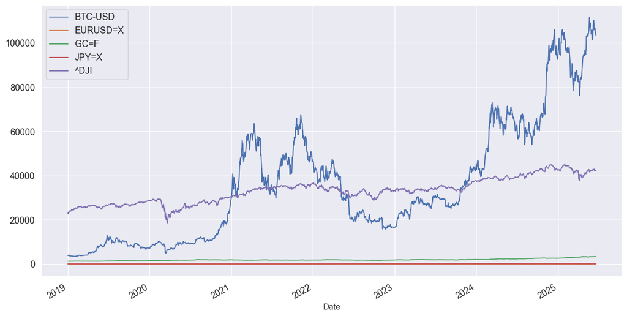

```python
close.dropna().plot(figsize = (15,8), fontsize = 13)
plt.legend(fontsize = 13)
plt.show()
```

```python
close.info()
```

```
<class 'pandas.core.frame.DataFrame'>
DatetimeIndex: 2362 entries, 2019-01-02 to 2025-06-20
Data columns (total 5 columns):
 #   Column    Non-Null Count  Dtype
---  ------    --------------  -----
 0   BTC-USD   2362 non-null   float64
 1   EURUSD=X  1684 non-null   float64
 2   GC=F      1627 non-null   float64
 3   JPY=X     1684 non-null   float64
 4   ^DJI      1626 non-null   float64
dtypes: float64(5)
memory usage: 110.7 KB
```

```python
np.log(close / close.shift()).info() #keep NaN
```

```
<class 'pandas.core.frame.DataFrame'>
DatetimeIndex: 2362 entries, 2019-01-02 to 2025-06-20
Data columns (total 5 columns):
 #   Column    Non-Null Count  Dtype
---  ------    --------------  -----
 0   BTC-USD   2361 non-null   float64
 1   EURUSD=X  1344 non-null   float64
 2   GC=F      1274 non-null   float64
 3   JPY=X     1344 non-null   float64
 4   ^DJI      1272 non-null   float64
dtypes: float64(5)
memory usage: 110.7 KB
```

```python
close.apply(lambda x: np.log(x.dropna() / x.dropna().shift())).info() #remove NaN
```

```
<class 'pandas.core.frame.DataFrame'>
DatetimeIndex: 2362 entries, 2019-01-02 to 2025-06-20
Freq: D
Data columns (total 5 columns):
 #   Column    Non-Null Count  Dtype
---  ------    --------------  -----
 0   BTC-USD   2361 non-null   float64
 1   EURUSD=X  1683 non-null   float64
 2   GC=F      1626 non-null   float64
 3   JPY=X     1683 non-null   float64
 4   ^DJI      1625 non-null   float64
dtypes: float64(5)
memory usage: 110.7 KB
```

```python
returns = close.apply(lambda x: np.log(x.dropna() / x.dropna().shift()))
returns
```

| Date | BTC-USD | EURUSD=X | GC=F | JPY=X | ^DJI |
| --- | --- | --- | --- | --- | --- |
| 2019-01-02 | NaN | NaN | NaN | NaN | NaN |
| 2019-01-03 | -0.02742 | -0.01261 | 0.008396 | -0.02052 | -0.02868 |
| 2019-01-04 | 0.005452 | 0.006427 | -0.007069 | 0.00341 | 0.03239 |
| 2019-01-05 | -0.003251 | NaN | NaN | NaN | NaN |
| 2019-01-06 | 0.05845 | NaN | NaN | NaN | NaN |
| ... | ... | ... | ... | ... | ... |
| 2025-06-16 | 0.01172 | -0.003763 | -0.01019 | 0.006245 | 0.007491 |
| 2025-06-17 | -0.02077 | -0.0004621 | -0.00289 | 0.004418 | -0.007064 |
| 2025-06-18 | 0.002694 | -0.005966 | 0.0009444 | 0.00446 | -0.001046 |
| 2025-06-19 | -0.0019 | -0.0004478 | NaN | -0.0029 | NaN |
| 2025-06-20 | -0.01322 | 0.003069 | -0.006422 | 0.001813 | 0.0008334 |

2362 rows × 5 columns

```python
returns.info()
```

```
<class 'pandas.core.frame.DataFrame'>
DatetimeIndex: 2362 entries, 2019-01-02 to 2025-06-20
Freq: D
Data columns (total 5 columns):
 #   Column    Non-Null Count  Dtype
---  ------    --------------  -----
 0   BTC-USD   2361 non-null   float64
 1   EURUSD=X  1683 non-null   float64
 2   GC=F      1626 non-null   float64
 3   JPY=X     1683 non-null   float64
 4   ^DJI      1625 non-null   float64
dtypes: float64(5)
memory usage: 110.7 KB
```

```python
returns.describe()
```

|  | BTC-USD | EURUSD=X | GC=F | JPY=X | ^DJI |
| --- | --- | --- | --- | --- | --- |
| count | 2.361e+03 | 1.683e+03 | 1.626e+03 | 1.683e+03 | 1.625e+03 |
| mean | 0.001383 | 2.641e-06 | 0.0005945 | 0.0001668 | 0.0003644 |
| std | 0.03369 | 0.004593 | 0.01011 | 0.005671 | 0.01251 |
| min | -0.4647 | -0.02814 | -0.05107 | -0.03796 | -0.1384 |
| 25% | -0.01286 | -0.002586 | -0.004197 | -0.002504 | -0.004422 |
| 50% | 0.0007546 | -7.6e-05 | 0.0007968 | 0.0003824 | 0.0007432 |
| 75% | 0.01581 | 0.002617 | 0.006154 | 0.003126 | 0.005972 |
| max | 0.1718 | 0.02754 | 0.05778 | 0.02669 | 0.1076 |

```python
summary = returns.agg(['mean', 'std']).T
summary
```

|  | mean | std |
| --- | --- | --- |
| BTC-USD | 0.001383 | 0.03369 |
| EURUSD=X | 2.641e-06 | 0.004593 |
| GC=F | 0.0005945 | 0.01011 |
| JPY=X | 0.0001668 | 0.005671 |
| ^DJI | 0.0003644 | 0.01251 |

```python
summary.columns = ['Mean','Std']
summary
```

|  | Mean | Std |
| --- | --- | --- |
| BTC-USD | 0.001383 | 0.03369 |
| EURUSD=X | 2.641e-06 | 0.004593 |
| GC=F | 0.0005945 | 0.01011 |
| JPY=X | 0.0001668 | 0.005671 |
| ^DJI | 0.0003644 | 0.01251 |

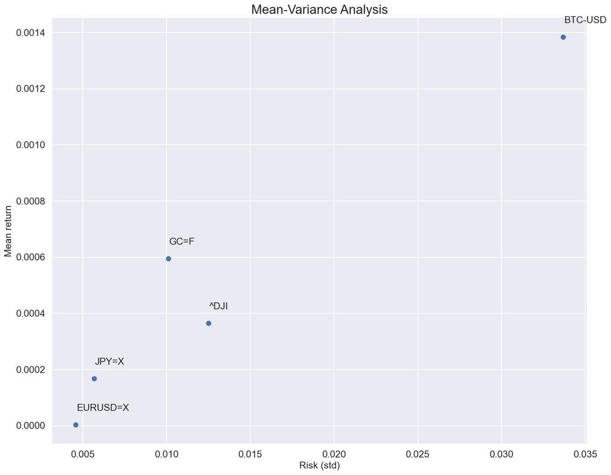

```python
summary.plot(kind = 'scatter', x='Std', y='Mean', figsize = (15,12), s = 50, fontsize = 15)
for i in summary.index:
    plt.annotate(i, xy=(summary.loc[i, 'Std']+0.00005, summary.loc[i, 'Mean']+0.00005), size = 15)
plt.xlabel('Risk (std)', fontsize = 15)
plt.ylabel('Mean return', fontsize = 15)
plt.title('Mean-Variance Analysis', fontsize = 20)
plt.show()
```

# Normality of Financial Returns

```python
usdjpy = pd.read_csv('usdjpy.csv', index_col='Date', parse_dates=['Date'])
usdjpy
```

| Date | Price | Returns |
| --- | --- | --- |
| 2019-01-02 | 109.7 | NaN |
| 2019-01-03 | 107.4 | -0.02031 |
| 2019-01-04 | 107.8 | 0.003416 |
| 2019-01-07 | 108.5 | 0.006623 |
| 2019-01-08 | 108.6 | 0.0008661 |
| ... | ... | ... |
| 2025-06-16 | 144.1 | 0.006264 |
| 2025-06-17 | 144.7 | 0.004428 |
| 2025-06-18 | 145.4 | 0.00447 |
| 2025-06-19 | 145.0 | -0.002896 |
| 2025-06-20 | 145.2 | 0.001814 |

1684 rows × 2 columns

```python
usdjpy['log_ret'] = np.log(usdjpy.Price / usdjpy.Price.shift())
usdjpy
```

| Date | Price | Returns | log_ret |
| --- | --- | --- | --- |
| 2019-01-02 | 109.7 | NaN | NaN |
| 2019-01-03 | 107.4 | -0.02031 | -0.02052 |
| 2019-01-04 | 107.8 | 0.003416 | 0.00341 |
| 2019-01-07 | 108.5 | 0.006623 | 0.006601 |
| 2019-01-08 | 108.6 | 0.0008661 | 0.0008658 |
| ... | ... | ... | ... |
| 2025-06-16 | 144.1 | 0.006264 | 0.006245 |
| 2025-06-17 | 144.7 | 0.004428 | 0.004418 |
| 2025-06-18 | 145.4 | 0.00447 | 0.00446 |
| 2025-06-19 | 145.0 | -0.002896 | -0.0029 |
| 2025-06-20 | 145.2 | 0.001814 | 0.001813 |

1684 rows × 3 columns

```python
usdjpy.describe()
```

|  | Price | Returns | log_ret |
| --- | --- | --- | --- |
| count | 1.684e+03 | 1.683e+03 | 1.683e+03 |
| mean | 126.5 | 0.0001829 | 0.0001668 |
| std | 18.69 | 0.005666 | 0.005671 |
| min | 102.7 | -0.03725 | -0.03796 |
| 25% | 108.9 | -0.0025 | -0.002504 |
| 50% | 121.9 | 0.0003825 | 0.0003824 |
| 75% | 145.0 | 0.00313 | 0.003126 |
| max | 161.6 | 0.02705 | 0.02669 |

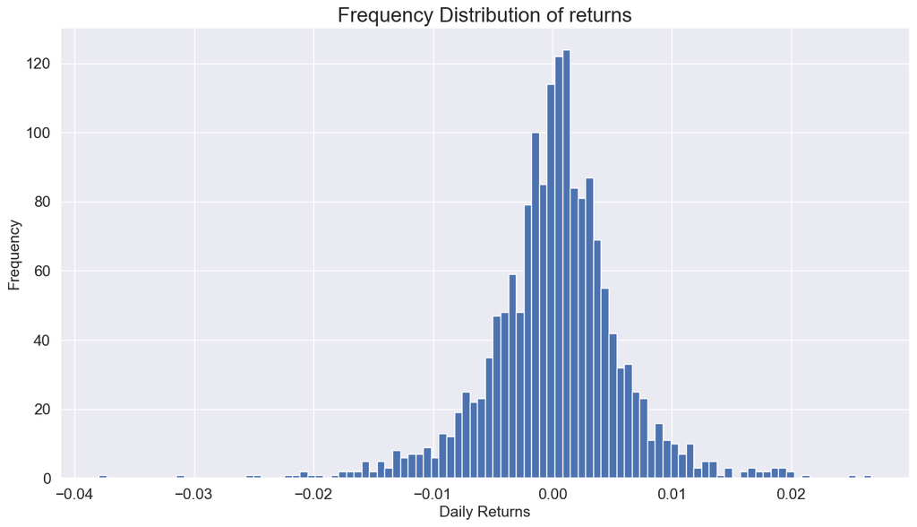

```python
usdjpy.log_ret.plot(kind = 'hist', figsize = (15,8), bins = 100, fontsize = 15, density = False)
plt.xlabel('Daily Returns', fontsize = 15)
plt.ylabel('Frequency', fontsize = 15)
plt.title('Frequency Distribution of returns', fontsize = 20)
plt.show()
```

do USDJPY Returns follow a Normal Distribution?  
A normal distributed random variable can be fully described by its

Mean

Standard Deviation

Higher central moments are zero:

Skew = 0 (measures symmetrie around the mean)

(Excess) Kurtosis = 0 (positive excess kurtosis -> more observations in the 'tails')

```python
mu = usdjpy.log_ret.mean()
mu
```

```
0.00016683212372041329
```

```python
sigma = usdjpy.log_ret.std()
sigma
```

```
0.005671072828636655
```

```python
import scipy.stats as stats
```

```python
stats.skew(usdjpy.log_ret.dropna()) #in a Normal Distribution: skew == 0
```

```
-0.3661104806580219
```

This mean USDJPY Slightly left skew

```python
stats.kurtosis(usdjpy.log_ret.dropna(), fisher = True) #in a normal distribution: (fisher)kurtosis == 0
```

```
3.8386699321824036
```

-> this means, USDJPY Returns exhibit 'Fat Tails' (extreme positive/negative outcomes).

```python
x = np.linspace(usdjpy.log_ret.min(), usdjpy.log_ret.max(), 10000)
x
```

```
array([-0.037961  , -0.03795453, -0.03794807, ...,  0.02667644,
        0.02668291,  0.02668937])
```

```python
y = stats.norm.pdf(x, loc = mu, scale = sigma) #creating y value a for normal distribution with mu, sigma
y
```

```
array([1.07607538e-08, 1.08435475e-08, 1.09269640e-08, ...,
       1.26563078e-03, 1.25890271e-03, 1.25220878e-03])
```

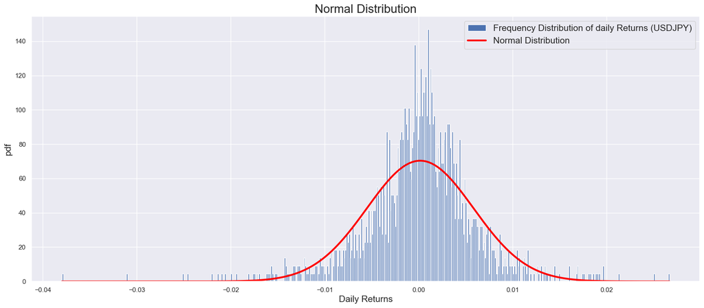

```python
plt.figure(figsize = (20,8))
plt.hist(usdjpy.log_ret, bins = 500, density = True, label = 'Frequency Distribution of daily Returns (USDJPY)')
plt.plot(x, y, linewidth = 3, color = 'red', label = 'Normal Distribution')
plt.title('Normal Distribution', fontsize = 20)
plt.xlabel('Daily Returns', fontsize = 15)
plt.ylabel('pdf', fontsize =15)
plt.legend(fontsize = 15)
plt.show()
```

-> USDJPY Returns exhibit 'Fat Tails' (extreme positive/negative outcomes).

Testing the normality of USDJPY Returns based o the sample:  
-> Hypotesis Test with H0 Hypothesis: USDJPY Returns (full population) follow a normal Distribution.

```python
z_stat, p_value = stats.normaltest(usdjpy.log_ret.dropna())
```

```python
z_stat # high values -> reject H0
```

```
190.46223319157687
```

```python
p_value # low values (close to zero) -> reject H0
```

```
4.38178997046346e-42
```

```python
round(p_value, 10)
```

```
0.0
```

-> Assuming that USDJPY Returns (generally) follow a Normal Distribution, there is 0% probability that we get that extreme outcomes in a sample.  
USDJPY Returns don't follow a Normal Distribution as they exhibit 'Fat Tails'. Extreme Events/Outcomes are not reflected in the Mean-Variance Analysis. The Standard Deviation of Returns underestimates true Risk.

Dengan demikian, USDJPY tidak dalam Normal Distribution karena dia exhibit extreme values of returns dan bila dia mengikuti distribusi normal adalah 0% dia akan menghasilkan hasil ekstrim. Ini pun telah divalidasi dari gambar dan test statistics.

# Annualizing Mean Return and Std of Returns

```python
usdjpy = pd.read_csv('usdjpy.csv', index_col='Date', parse_dates=['Date'])
usdjpy
```

| Date | Price | Returns |
| --- | --- | --- |
| 2019-01-02 | 109.7 | NaN |
| 2019-01-03 | 107.4 | -0.02031 |
| 2019-01-04 | 107.8 | 0.003416 |
| 2019-01-07 | 108.5 | 0.006623 |
| 2019-01-08 | 108.6 | 0.0008661 |
| ... | ... | ... |
| 2025-06-16 | 144.1 | 0.006264 |
| 2025-06-17 | 144.7 | 0.004428 |
| 2025-06-18 | 145.4 | 0.00447 |
| 2025-06-19 | 145.0 | -0.002896 |
| 2025-06-20 | 145.2 | 0.001814 |

1684 rows × 2 columns

```python
usdjpy['log_ret'] = np.log(usdjpy.Price / usdjpy.Price.shift())
usdjpy
```

| Date | Price | Returns | log_ret |
| --- | --- | --- | --- |
| 2019-01-02 | 109.7 | NaN | NaN |
| 2019-01-03 | 107.4 | -0.02031 | -0.02052 |
| 2019-01-04 | 107.8 | 0.003416 | 0.00341 |
| 2019-01-07 | 108.5 | 0.006623 | 0.006601 |
| 2019-01-08 | 108.6 | 0.0008661 | 0.0008658 |
| ... | ... | ... | ... |
| 2025-06-16 | 144.1 | 0.006264 | 0.006245 |
| 2025-06-17 | 144.7 | 0.004428 | 0.004418 |
| 2025-06-18 | 145.4 | 0.00447 | 0.00446 |
| 2025-06-19 | 145.0 | -0.002896 | -0.0029 |
| 2025-06-20 | 145.2 | 0.001814 | 0.001813 |

1684 rows × 3 columns

```python
usdjpy.log_ret.agg(['mean', 'std']) # mean and std based on daily returns
```

```
mean   0.0001668
std     0.005671
Name: log_ret, dtype: float64
```

```python
ann_mu = usdjpy.log_ret.mean() * 252 # annualized mean return
ann_mu
```

```
0.04204169517754415
```

```python
cagr = np.exp(ann_mu) - 1 # dont mix up with cagr
cagr
```

```
0.0429379633277569
```

```python
ann_std = usdjpy.log_ret.std() * np.sqrt(252) # annualized std of returns (alt 1)
ann_std
```

```
0.09002549022904924
```

```python
ann_std = np.sqrt(usdjpy.log_ret.var() * 252) # annualized std of returns (alt 2)
ann_std
```

```
0.09002549022904924
```

# Resampling / Smoothing

```python
usdjpy.head(25)
```

| Date | Price | Returns | log_ret |
| --- | --- | --- | --- |
| 2019-01-02 | 109.7 | NaN | NaN |
| 2019-01-03 | 107.4 | -0.02031 | -0.02052 |
| 2019-01-04 | 107.8 | 0.003416 | 0.00341 |
| 2019-01-07 | 108.5 | 0.006623 | 0.006601 |
| 2019-01-08 | 108.6 | 0.0008661 | 0.0008658 |
| 2019-01-09 | 108.8 | 0.001473 | 0.001472 |
| 2019-01-10 | 108.2 | -0.005396 | -0.005411 |
| 2019-01-11 | 108.3 | 0.001007 | 0.001007 |
| 2019-01-14 | 108.5 | 0.001477 | 0.001476 |
| 2019-01-15 | 108.2 | -0.001918 | -0.00192 |
| 2019-01-16 | 108.6 | 0.00364 | 0.003633 |
| 2019-01-17 | 109.0 | 0.003617 | 0.003611 |
| 2019-01-18 | 109.2 | 0.001064 | 0.001063 |
| 2019-01-21 | 109.7 | 0.004654 | 0.004643 |
| 2019-01-22 | 109.7 | 8.203e-05 | 8.202e-05 |
| 2019-01-23 | 109.4 | -0.002872 | -0.002876 |
| 2019-01-24 | 109.5 | 0.001253 | 0.001252 |
| 2019-01-25 | 109.6 | 0.000959 | 0.0009585 |
| 2019-01-28 | 109.4 | -0.001797 | -0.001799 |
| 2019-01-29 | 109.3 | -0.001335 | -0.001335 |
| 2019-01-30 | 109.4 | 0.001492 | 0.001491 |
| 2019-01-31 | 109.0 | -0.003985 | -0.003993 |
| 2019-02-01 | 108.8 | -0.001257 | -0.001258 |
| 2019-02-04 | 109.4 | 0.005457 | 0.005443 |
| 2019-02-05 | 110.0 | 0.004779 | 0.004768 |

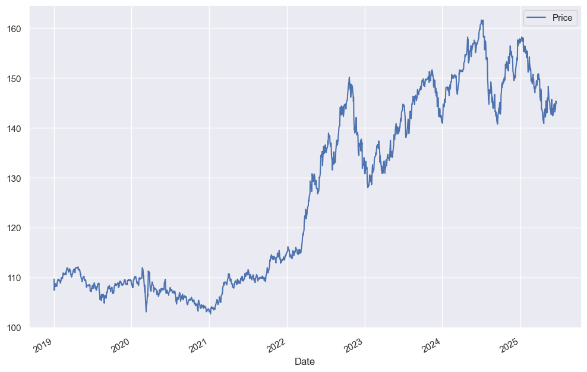

```python
usdjpy.Price.plot(figsize = (12,8))
plt.legend()
plt.show()
```

```python
monthly = usdjpy.Price.resample('ME').last() ## resample to montly (month end)
monthly
```

```
Date
2019-01-31   109.0
2019-02-28   110.9
2019-03-31   110.6
2019-04-30   111.7
2019-05-31   109.4
              ...
2025-02-28   150.0
2025-03-31   149.6
2025-04-30   142.3
2025-05-31   143.8
2025-06-30   145.2
Freq: ME, Name: Price, Length: 78, dtype: float64
```

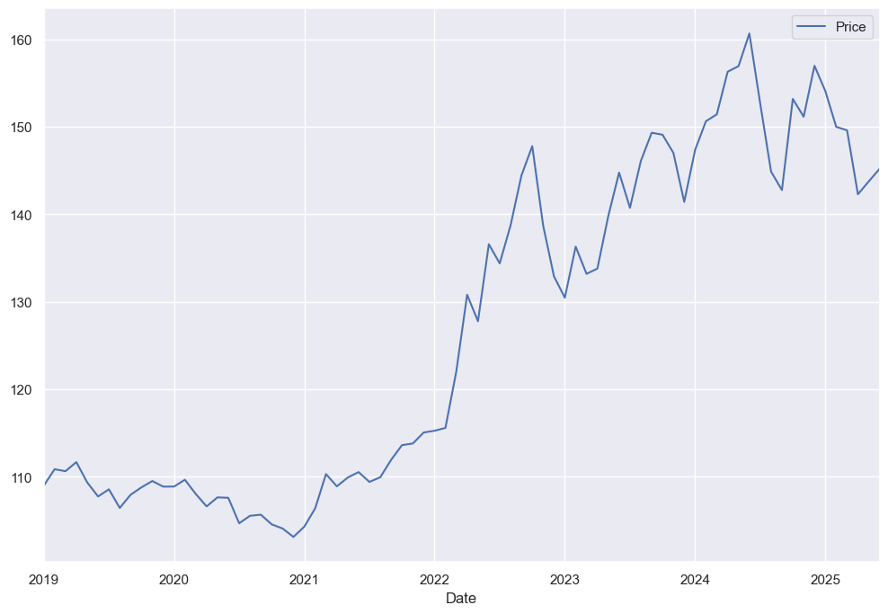

```python
monthly.plot(figsize = (12,8))
plt.legend()
plt.show()
```

```python
freqs = ["YE", "QE", "ME", "W-FRI", "D"]
periods = [1, 4, 12, 52, 252]
ann_mean = []
ann_std = []
```

```python
for i in range(5):
    resamp = usdjpy.Price.resample(freqs[i]).last() # resample
    ann_mean.append(np.log(resamp / resamp.shift()).mean() * periods[i]) # calc. annualized mean
    ann_std.append(np.log(resamp / resamp.shift()).std() * np.sqrt(periods[i])) # calc. annualized stdann_mean
```

```python
ann_mean
```

```
[0.048009000369349665,
 0.04351703939538656,
 0.04473701248053362,
 0.04596433112257546,
 0.04048135609369839]
```

```python
ann_std
```

```
[0.09248265818123826,
 0.112314893004163,
 0.09515299063316236,
 0.09146490495755166,
 0.08759742654430182]
```

```python
summary = pd.DataFrame(data = {"ann_std":ann_std, "ann_mean":ann_mean}, index = freqs)
summary
```

|  | ann_std | ann_mean |
| --- | --- | --- |
| YE | 0.09248 | 0.04801 |
| QE | 0.1123 | 0.04352 |
| ME | 0.09515 | 0.04474 |
| W-FRI | 0.09146 | 0.04596 |
| D | 0.0876 | 0.04048 |

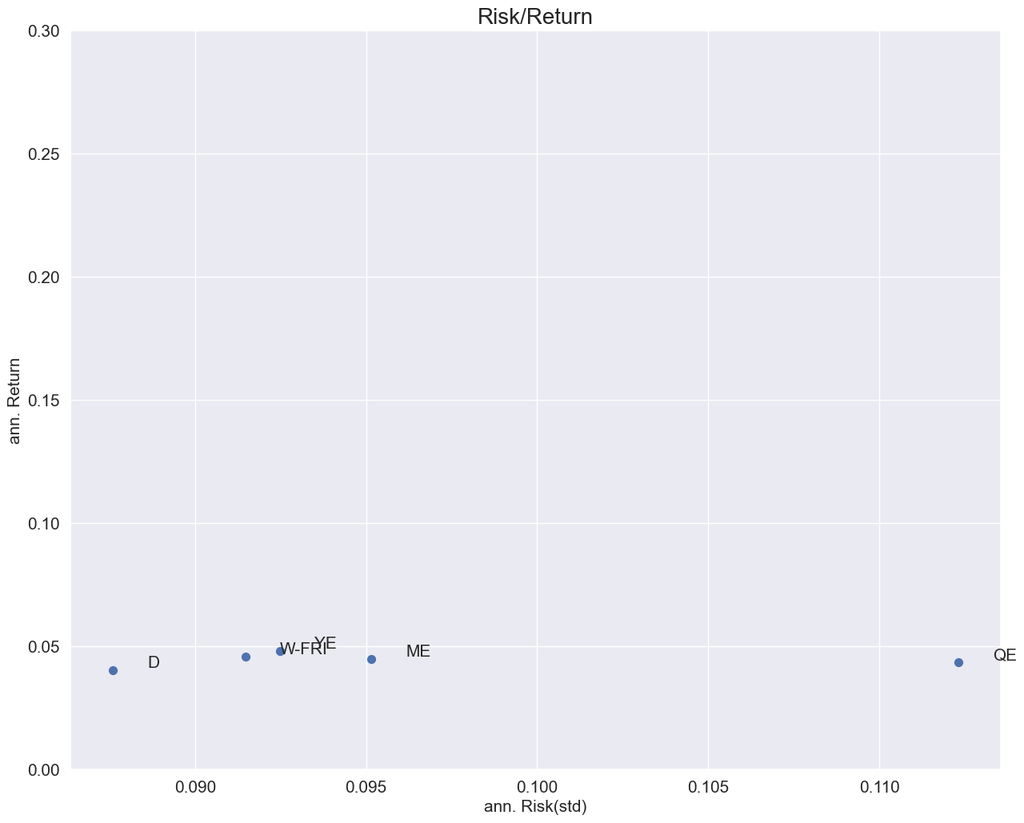

```python
summary.plot(kind = "scatter", x = "ann_std", y = "ann_mean", figsize = (15,12), s = 50, fontsize = 15)
for i in summary.index:
    plt.annotate(i, xy=(summary.loc[i, "ann_std"]+0.001, summary.loc[i, "ann_mean"]+0.001), size = 15)
plt.ylim(0, 0.3)
plt.xlabel("ann. Risk(std)", fontsize = 15)
plt.ylabel("ann. Return", fontsize = 15)
plt.title("Risk/Return", fontsize = 20)
plt.show()
```

-> Smoothing for forex (USDJPY) doesnt reduce (observed) Risk.

When comparing instrument, frequency of underlying data must be the same! Dont compare apples and oranges!

# Rolling Statistics

(Another) General Rule in Finance/Investing: Past performance is not an indicator of future performance.

```python
usdjpy
```

| Date | Price | Returns | log_ret |
| --- | --- | --- | --- |
| 2019-01-02 | 109.7 | NaN | NaN |
| 2019-01-03 | 107.4 | -0.02031 | -0.02052 |
| 2019-01-04 | 107.8 | 0.003416 | 0.00341 |
| 2019-01-07 | 108.5 | 0.006623 | 0.006601 |
| 2019-01-08 | 108.6 | 0.0008661 | 0.0008658 |
| ... | ... | ... | ... |
| 2025-06-16 | 144.1 | 0.006264 | 0.006245 |
| 2025-06-17 | 144.7 | 0.004428 | 0.004418 |
| 2025-06-18 | 145.4 | 0.00447 | 0.00446 |
| 2025-06-19 | 145.0 | -0.002896 | -0.0029 |
| 2025-06-20 | 145.2 | 0.001814 | 0.001813 |

1684 rows × 3 columns

```python
ann_mu = usdjpy.log_ret.mean() * 252 # annualized mean return
ann_mu
```

```
0.04204169517754415
```

```python
ann_std = usdjpy.log_ret.std() * np.sqrt(252) # annualized std of returns (Alt 1)
ann_std
```

```
0.09002549022904924
```

**Are Return and Risk constant over time? No, of course not! They change over time.**

**Let´s measure/quantify this with rolling statistics!**

```python
window = 252 # rolling window 252 trading days (~ 1 Year)
```

```python
usdjpy.log_ret.rolling(window = 252)
```

```
Rolling [window=252,center=False,axis=0,method=single]
```

```python
roll_mean = usdjpy.log_ret.rolling(window = 252).mean() * 252 # Alt 2
roll_mean
```

```
Date
2019-01-02        NaN
2019-01-03        NaN
2019-01-04        NaN
2019-01-07        NaN
2019-01-08        NaN
               ...
2025-06-16    -0.1039
2025-06-17   -0.09835
2025-06-18   -0.09389
2025-06-19    -0.1026
2025-06-20    -0.1012
Name: log_ret, Length: 1684, dtype: float64
```

```python
roll_mean.iloc[250:]
```

```
Date
2019-12-19         NaN
2019-12-20         NaN
2019-12-23   -0.001542
2019-12-24      0.0179
2019-12-25      0.0145
                ...
2025-06-16     -0.1039
2025-06-17    -0.09835
2025-06-18    -0.09389
2025-06-19     -0.1026
2025-06-20     -0.1012
Name: log_ret, Length: 1434, dtype: float64
```

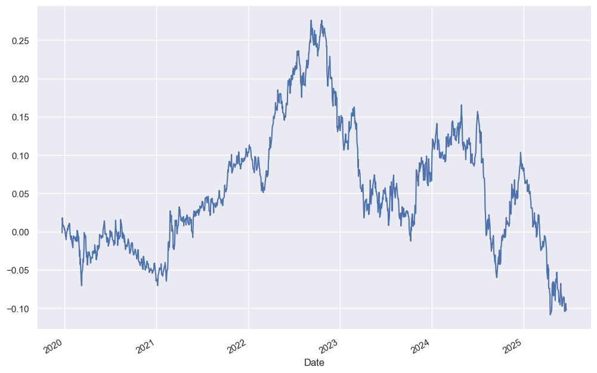

```python
roll_mean.plot(figsize = (12, 8))
plt.show()
```

```python
roll_std = usdjpy.log_ret.rolling(window = 252).std() * np.sqrt(252)
roll_std
```

```
Date
2019-01-02      NaN
2019-01-03      NaN
2019-01-04      NaN
2019-01-07      NaN
2019-01-08      NaN
              ...
2025-06-16   0.1151
2025-06-17   0.1152
2025-06-18   0.1153
2025-06-19   0.1152
2025-06-20   0.1152
Name: log_ret, Length: 1684, dtype: float64
```

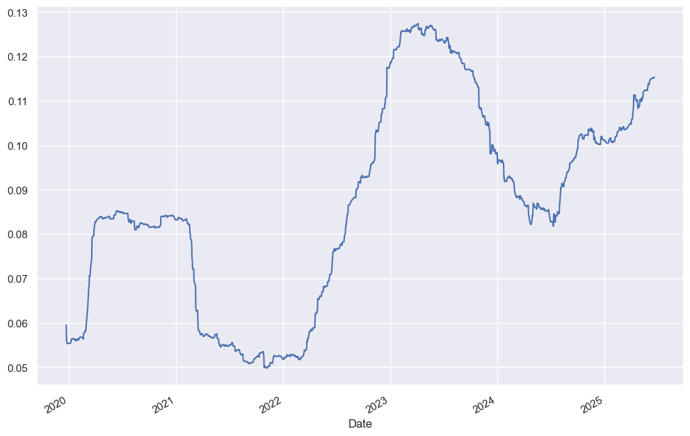

```python
roll_std.plot(figsize = (12, 8))
plt.show()
```

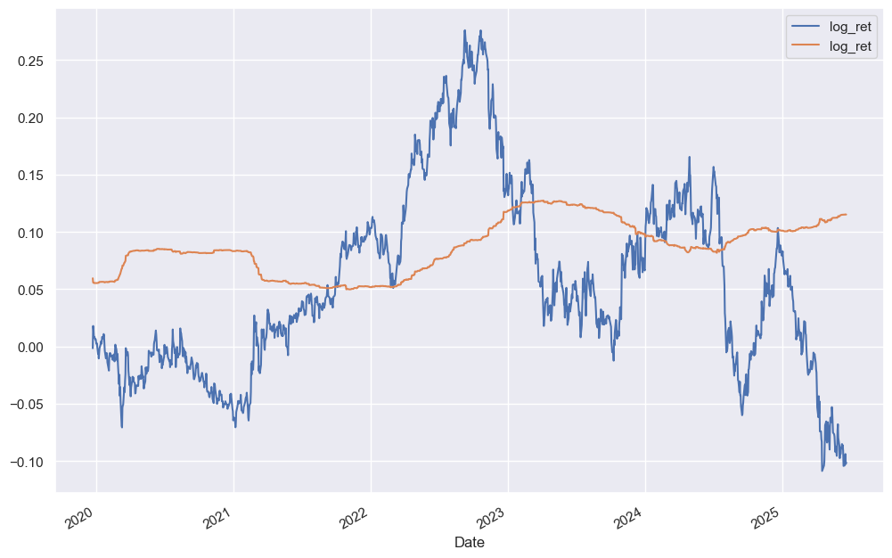

```python
roll_mean.plot(figsize = (12, 8))
roll_std.plot()
plt.legend()
plt.show()
```

Be careful, you´ll always find (sub-)periods with **low returns & high risk** and **high returns & low risk**.

- Analysis Period must be **sufficiently long** to reduce impact of random noise.
- Analysis Period should be **as short as possible** and should only include the **latest trends / regimes**.
- Commonly used reporting period: **3 Years / 36 Months**

Interpretation

```
You can observe how the expected return and risk (volatility) of the USD/JPY forex pair change over time.

Useful for risk management, regime detection, or volatility forecasting.
```

Main Concept: Rolling Statistics

Rolling statistics (like rolling mean and rolling standard deviation) are used to:

```
Analyze how returns and risk evolve over time

Identify changing regimes in performance

Avoid relying too heavily on long-term averages that may hide important fluctuations
```

Why Use Rolling Statistics?  
Problem with Using Full-Period Averages:

[output not shown]

Rolling Window Solution:

```
Use a moving time window, e.g. 252 trading days (~1 year)

At each point in time, compute return and risk based on the latest 252 data points

This helps reveal temporal shifts in performance and volatility
```

so simply it show how return and std change over time hence past performance doesnt reflect future performance because the return is changing

**Another Example: Simple Moving Average (Prices) - SMA**

```python
sma_window = 50
```

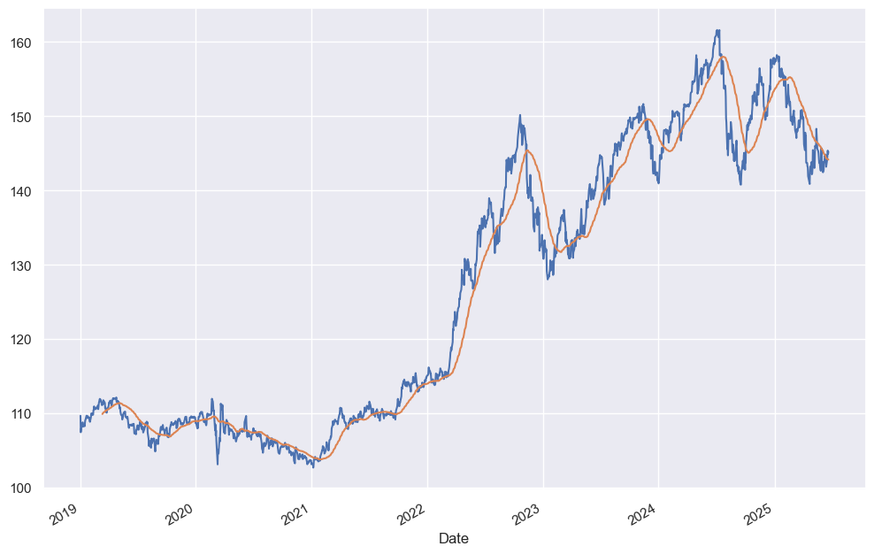

```python
usdjpy.Price.plot(figsize = (12, 8))
usdjpy.Price.rolling(sma_window).mean().plot()
plt.show()
```

# Short Selling / Short Position

why we need to use log return:  
Simple returns depend on where you start So:

```
+50% and −50% don’t cancel each other

+13.64% and −13.64% are not opposites
```

therefore, they are not symmetric.

-> For simple returns: long position returns != short position returns * (-1)  
-> For log returns: long position returns == short position returns * (-1)

```python
close = pd.read_csv("close.csv", index_col = "Date", parse_dates = ["Date"])
close
```

| Date | BTC-USD | EURUSD=X | GC=F | JPY=X | ^DJI |
| --- | --- | --- | --- | --- | --- |
| 2019-01-02 | 3.943e+03 | 1.146 | 1.281e+03 | 109.7 | 2.335e+04 |
| 2019-01-03 | 3.837e+03 | 1.132 | 1.292e+03 | 107.4 | 2.269e+04 |
| 2019-01-04 | 3.858e+03 | 1.139 | 1.283e+03 | 107.8 | 2.343e+04 |
| 2019-01-05 | 3.845e+03 | NaN | NaN | NaN | NaN |
| 2019-01-06 | 4.077e+03 | NaN | NaN | NaN | NaN |
| ... | ... | ... | ... | ... | ... |
| 2025-06-16 | 1.068e+05 | 1.156 | 3.396e+03 | 144.1 | 4.252e+04 |
| 2025-06-17 | 1.046e+05 | 1.155 | 3.387e+03 | 144.7 | 4.222e+04 |
| 2025-06-18 | 1.049e+05 | 1.148 | 3.39e+03 | 145.4 | 4.217e+04 |
| 2025-06-19 | 1.047e+05 | 1.148 | NaN | 145.0 | NaN |
| 2025-06-20 | 1.033e+05 | 1.151 | 3.368e+03 | 145.2 | 4.221e+04 |

2362 rows × 5 columns

```python
close["USDEUR=X"] = 1/close["EURUSD=X"]
```

```python
close
```

| Date | BTC-USD | EURUSD=X | GC=F | JPY=X | ^DJI | USDEUR=X |
| --- | --- | --- | --- | --- | --- | --- |
| 2019-01-02 | 3.943e+03 | 1.146 | 1.281e+03 | 109.7 | 2.335e+04 | 0.8725 |
| 2019-01-03 | 3.837e+03 | 1.132 | 1.292e+03 | 107.4 | 2.269e+04 | 0.8835 |
| 2019-01-04 | 3.858e+03 | 1.139 | 1.283e+03 | 107.8 | 2.343e+04 | 0.8779 |
| 2019-01-05 | 3.845e+03 | NaN | NaN | NaN | NaN | NaN |
| 2019-01-06 | 4.077e+03 | NaN | NaN | NaN | NaN | NaN |
| ... | ... | ... | ... | ... | ... | ... |
| 2025-06-16 | 1.068e+05 | 1.156 | 3.396e+03 | 144.1 | 4.252e+04 | 0.8653 |
| 2025-06-17 | 1.046e+05 | 1.155 | 3.387e+03 | 144.7 | 4.222e+04 | 0.8657 |
| 2025-06-18 | 1.049e+05 | 1.148 | 3.39e+03 | 145.4 | 4.217e+04 | 0.8709 |
| 2025-06-19 | 1.047e+05 | 1.148 | NaN | 145.0 | NaN | 0.8713 |
| 2025-06-20 | 1.033e+05 | 1.151 | 3.368e+03 | 145.2 | 4.221e+04 | 0.8686 |

2362 rows × 6 columns

```python
fx = close[["EURUSD=X", "USDEUR=X"]].dropna().copy()
```

```python
fx
```

| Date | EURUSD=X | USDEUR=X |
| --- | --- | --- |
| 2019-01-02 | 1.146 | 0.8725 |
| 2019-01-03 | 1.132 | 0.8835 |
| 2019-01-04 | 1.139 | 0.8779 |
| 2019-01-07 | 1.141 | 0.8764 |
| 2019-01-08 | 1.148 | 0.8711 |
| ... | ... | ... |
| 2025-06-16 | 1.156 | 0.8653 |
| 2025-06-17 | 1.155 | 0.8657 |
| 2025-06-18 | 1.148 | 0.8709 |
| 2025-06-19 | 1.148 | 0.8713 |
| 2025-06-20 | 1.151 | 0.8686 |

1684 rows × 2 columns

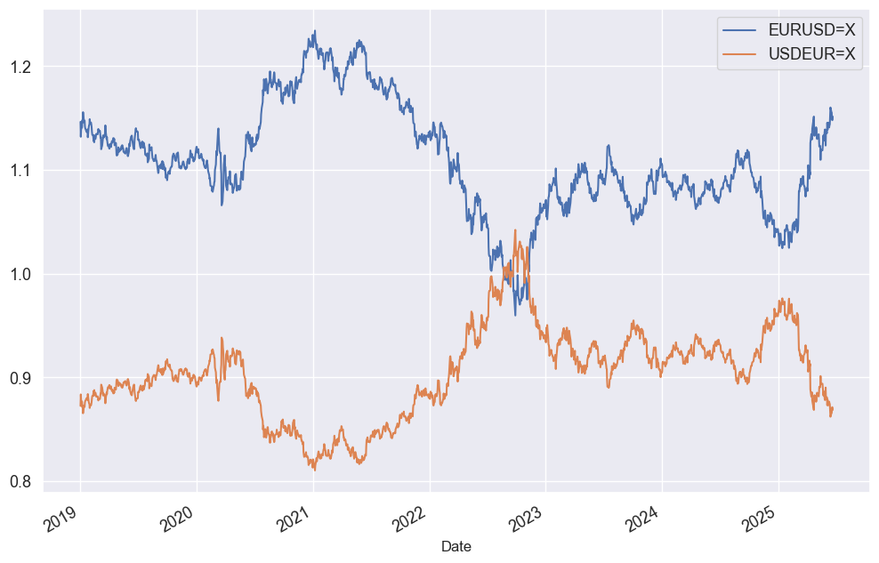

```python
fx.plot(figsize = (12,8), fontsize = 13)
plt.legend(fontsize = 13)
plt.show()
```

```python
simple_ret = fx.pct_change() # simple returns
simple_ret
```

| Date | EURUSD=X | USDEUR=X |
| --- | --- | --- |
| 2019-01-02 | NaN | NaN |
| 2019-01-03 | -0.01253 | 0.01269 |
| 2019-01-04 | 0.006447 | -0.006406 |
| 2019-01-07 | 0.0017 | -0.001697 |
| 2019-01-08 | 0.006073 | -0.006036 |
| ... | ... | ... |
| 2025-06-16 | -0.003756 | 0.00377 |
| 2025-06-17 | -0.000462 | 0.0004622 |
| 2025-06-18 | -0.005948 | 0.005984 |
| 2025-06-19 | -0.0004477 | 0.0004479 |
| 2025-06-20 | 0.003074 | -0.003065 |

1684 rows × 2 columns

```python
simple_ret.add(1).prod() - 1 # compound simple returns
```

```
EURUSD=X    0.004455
USDEUR=X   -0.004436
dtype: float64
```

**-> For simple returns: long position returns != short position returns * (-1)**

```python
log_ret = np.log(fx / fx.shift()) # log returns
log_ret
```

| Date | EURUSD=X | USDEUR=X |
| --- | --- | --- |
| 2019-01-02 | NaN | NaN |
| 2019-01-03 | -0.01261 | 0.01261 |
| 2019-01-04 | 0.006427 | -0.006427 |
| 2019-01-07 | 0.001699 | -0.001699 |
| 2019-01-08 | 0.006054 | -0.006054 |
| ... | ... | ... |
| 2025-06-16 | -0.003763 | 0.003763 |
| 2025-06-17 | -0.0004621 | 0.0004621 |
| 2025-06-18 | -0.005966 | 0.005966 |
| 2025-06-19 | -0.0004478 | 0.0004478 |
| 2025-06-20 | 0.003069 | -0.003069 |

1684 rows × 2 columns

```python
log_ret.sum() # cumulative log returns
```

```
EURUSD=X    0.004446
USDEUR=X   -0.004446
dtype: float64
```

**-> For log returns: long position returns == short position returns * (-1)**

```python
norm_fx = log_ret.cumsum().apply(np.exp) # normalized prices (Base 1)
norm_fx
```

| Date | EURUSD=X | USDEUR=X |
| --- | --- | --- |
| 2019-01-02 | NaN | NaN |
| 2019-01-03 | 0.9875 | 1.013 |
| 2019-01-04 | 0.9938 | 1.006 |
| 2019-01-07 | 0.9955 | 1.004 |
| 2019-01-08 | 1.002 | 0.9984 |
| ... | ... | ... |
| 2025-06-16 | 1.008 | 0.9918 |
| 2025-06-17 | 1.008 | 0.9922 |
| 2025-06-18 | 1.002 | 0.9982 |
| 2025-06-19 | 1.001 | 0.9986 |
| 2025-06-20 | 1.004 | 0.9956 |

1684 rows × 2 columns

```python
norm_fx.iloc[0] = [1, 1]
```

```python
norm_fx
```

| Date | EURUSD=X | USDEUR=X |
| --- | --- | --- |
| 2019-01-02 | 1.0 | 1.0 |
| 2019-01-03 | 0.9875 | 1.013 |
| 2019-01-04 | 0.9938 | 1.006 |
| 2019-01-07 | 0.9955 | 1.004 |
| 2019-01-08 | 1.002 | 0.9984 |
| ... | ... | ... |
| 2025-06-16 | 1.008 | 0.9918 |
| 2025-06-17 | 1.008 | 0.9922 |
| 2025-06-18 | 1.002 | 0.9982 |
| 2025-06-19 | 1.001 | 0.9986 |
| 2025-06-20 | 1.004 | 0.9956 |

1684 rows × 2 columns

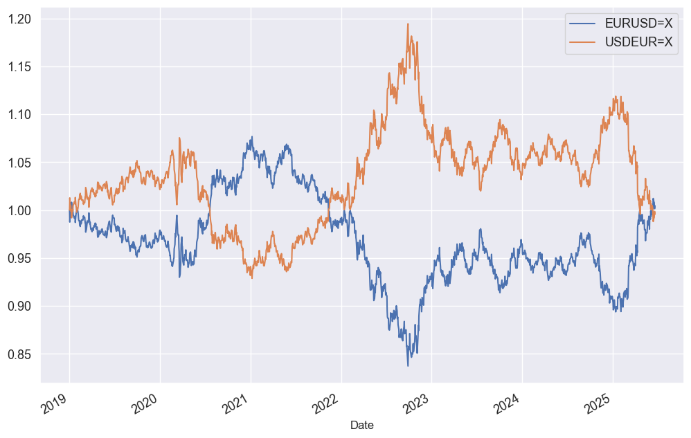

```python
norm_fx.plot(figsize = (12,8), fontsize = 13)
plt.legend(fontsize = 13)
plt.show()
```

# Covariance and Correlation

Do instruments/assets **move together** (and to what extent)?

Three cases:

- unrelated (**no** relationship/correlation)
- moving together (**positive** relationship/correlation)
- moving in opposite directions (**negative** relationship/correlation)

**-> Correlation between instruments/assets play an important role in portfolio management.**

```python
close = pd.read_csv("close.csv", index_col = "Date", parse_dates = ["Date"])
close
```

| Date | BTC-USD | EURUSD=X | GC=F | JPY=X | ^DJI |
| --- | --- | --- | --- | --- | --- |
| 2019-01-02 | 3.943e+03 | 1.146 | 1.281e+03 | 109.7 | 2.335e+04 |
| 2019-01-03 | 3.837e+03 | 1.132 | 1.292e+03 | 107.4 | 2.269e+04 |
| 2019-01-04 | 3.858e+03 | 1.139 | 1.283e+03 | 107.8 | 2.343e+04 |
| 2019-01-05 | 3.845e+03 | NaN | NaN | NaN | NaN |
| 2019-01-06 | 4.077e+03 | NaN | NaN | NaN | NaN |
| ... | ... | ... | ... | ... | ... |
| 2025-06-16 | 1.068e+05 | 1.156 | 3.396e+03 | 144.1 | 4.252e+04 |
| 2025-06-17 | 1.046e+05 | 1.155 | 3.387e+03 | 144.7 | 4.222e+04 |
| 2025-06-18 | 1.049e+05 | 1.148 | 3.39e+03 | 145.4 | 4.217e+04 |
| 2025-06-19 | 1.047e+05 | 1.148 | NaN | 145.0 | NaN |
| 2025-06-20 | 1.033e+05 | 1.151 | 3.368e+03 | 145.2 | 4.221e+04 |

2362 rows × 5 columns

```python
close["USDEUR=X"] = 1/close["EURUSD=X"]
close
```

| Date | BTC-USD | EURUSD=X | GC=F | JPY=X | ^DJI | USDEUR=X |
| --- | --- | --- | --- | --- | --- | --- |
| 2019-01-02 | 3.943e+03 | 1.146 | 1.281e+03 | 109.7 | 2.335e+04 | 0.8725 |
| 2019-01-03 | 3.837e+03 | 1.132 | 1.292e+03 | 107.4 | 2.269e+04 | 0.8835 |
| 2019-01-04 | 3.858e+03 | 1.139 | 1.283e+03 | 107.8 | 2.343e+04 | 0.8779 |
| 2019-01-05 | 3.845e+03 | NaN | NaN | NaN | NaN | NaN |
| 2019-01-06 | 4.077e+03 | NaN | NaN | NaN | NaN | NaN |
| ... | ... | ... | ... | ... | ... | ... |
| 2025-06-16 | 1.068e+05 | 1.156 | 3.396e+03 | 144.1 | 4.252e+04 | 0.8653 |
| 2025-06-17 | 1.046e+05 | 1.155 | 3.387e+03 | 144.7 | 4.222e+04 | 0.8657 |
| 2025-06-18 | 1.049e+05 | 1.148 | 3.39e+03 | 145.4 | 4.217e+04 | 0.8709 |
| 2025-06-19 | 1.047e+05 | 1.148 | NaN | 145.0 | NaN | 0.8713 |
| 2025-06-20 | 1.033e+05 | 1.151 | 3.368e+03 | 145.2 | 4.221e+04 | 0.8686 |

2362 rows × 6 columns

```python
returns = close.apply(lambda x: np.log(x.dropna() / x.dropna().shift()))
returns
```

| Date | BTC-USD | EURUSD=X | GC=F | JPY=X | ^DJI | USDEUR=X |
| --- | --- | --- | --- | --- | --- | --- |
| 2019-01-02 | NaN | NaN | NaN | NaN | NaN | NaN |
| 2019-01-03 | -0.02742 | -0.01261 | 0.008396 | -0.02052 | -0.02868 | 0.01261 |
| 2019-01-04 | 0.005452 | 0.006427 | -0.007069 | 0.00341 | 0.03239 | -0.006427 |
| 2019-01-05 | -0.003251 | NaN | NaN | NaN | NaN | NaN |
| 2019-01-06 | 0.05845 | NaN | NaN | NaN | NaN | NaN |
| ... | ... | ... | ... | ... | ... | ... |
| 2025-06-16 | 0.01172 | -0.003763 | -0.01019 | 0.006245 | 0.007491 | 0.003763 |
| 2025-06-17 | -0.02077 | -0.0004621 | -0.00289 | 0.004418 | -0.007064 | 0.0004621 |
| 2025-06-18 | 0.002694 | -0.005966 | 0.0009444 | 0.00446 | -0.001046 | 0.005966 |
| 2025-06-19 | -0.0019 | -0.0004478 | NaN | -0.0029 | NaN | 0.0004478 |
| 2025-06-20 | -0.01322 | 0.003069 | -0.006422 | 0.001813 | 0.0008334 | -0.003069 |

2362 rows × 6 columns

```python
returns.cov() # covariance (hard to interpret)
```

|  | BTC-USD | EURUSD=X | GC=F | JPY=X | ^DJI | USDEUR=X |
| --- | --- | --- | --- | --- | --- | --- |
| BTC-USD | 0.001135 | 8.618e-07 | 4.336e-05 | 3.661e-06 | 0.000142 | -8.618e-07 |
| EURUSD=X | 8.618e-07 | 2.11e-05 | 2.285e-06 | -1.195e-05 | 1.526e-06 | -2.11e-05 |
| GC=F | 4.336e-05 | 2.285e-06 | 0.0001021 | -1.395e-06 | 8.663e-06 | -2.285e-06 |
| JPY=X | 3.661e-06 | -1.195e-05 | -1.395e-06 | 3.216e-05 | -1.039e-06 | 1.195e-05 |
| ^DJI | 0.000142 | 1.526e-06 | 8.663e-06 | -1.039e-06 | 0.0001566 | -1.526e-06 |
| USDEUR=X | -8.618e-07 | -2.11e-05 | -2.285e-06 | 1.195e-05 | -1.526e-06 | 2.11e-05 |

```python
returns.corr() # correlation (easy to interpret)
```

|  | BTC-USD | EURUSD=X | GC=F | JPY=X | ^DJI | USDEUR=X |
| --- | --- | --- | --- | --- | --- | --- |
| BTC-USD | 1.0 | 0.005085 | 0.1155 | 0.0175 | 0.3055 | -0.005085 |
| EURUSD=X | 0.005085 | 1.0 | 0.04905 | -0.4588 | 0.02643 | -1.0 |
| GC=F | 0.1155 | 0.04905 | 1.0 | -0.02437 | 0.06849 | -0.04905 |
| JPY=X | 0.0175 | -0.4588 | -0.02437 | 1.0 | -0.01463 | 0.4588 |
| ^DJI | 0.3055 | 0.02643 | 0.06849 | -0.01463 | 1.0 | -0.02643 |
| USDEUR=X | -0.005085 | -1.0 | -0.04905 | 0.4588 | -0.02643 | 1.0 |

Three cases:

- no correlation: **correlation coefficient == 0**
- moving together: **0 < correlation coefficient <= 1** (positive)
- moving in opposite directions: **-1 <= correlation coefficient < 0** (negative)

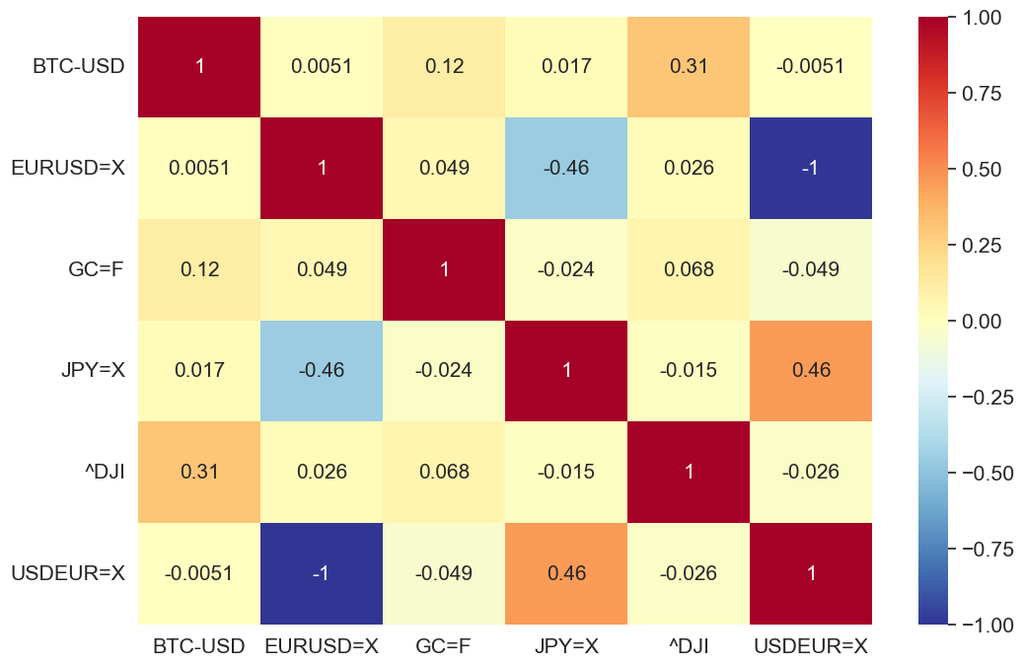

```python
import seaborn as sns
plt.figure(figsize=(12,8))
sns.set(font_scale=1.4)
sns.heatmap(returns.corr(), cmap = "RdYlBu_r", annot = True, annot_kws={"size":15}, vmin = -1, vmax = 1)
plt.show()
```

-> In portfolio management it´s beneficial to have assets with low/no/negative correlation (portfolio diversification effect).

# Portfolio of Assets and Portfolio Returns

```python
prices = pd.DataFrame(data = {"Asset_A": [100, 112], "Asset_B":[100, 104]}, index = [0, 1])
prices
```

|  | Asset_A | Asset_B |
| --- | --- | --- |
| 0 | 100 | 100 |
| 1 | 112 | 104 |

```python
prices["Total"] = prices.Asset_A + prices.Asset_B
```

```python
prices
```

|  | Asset_A | Asset_B | Total |
| --- | --- | --- | --- |
| 0 | 100 | 100 | 200 |
| 1 | 112 | 104 | 216 |

```python
returns = prices.pct_change() # simple returns
returns
```

|  | Asset_A | Asset_B | Total |
| --- | --- | --- | --- |
| 0 | NaN | NaN | NaN |
| 1 | 0.12 | 0.04 | 0.08 |

```python
0.5 * 0.12 + 0.5 * 0.04 # correct (portfolio return == weighted average of simple returns)
```

```
0.08
```

```python
log_returns = np.log(prices / prices.shift()) # log returns
log_returns
```

|  | Asset_A | Asset_B | Total |
| --- | --- | --- | --- |
| 0 | NaN | NaN | NaN |
| 1 | 0.1133 | 0.03922 | 0.07696 |

```python
0.5 * log_returns.iloc[1,0] + 0.5 * log_returns.iloc[1,1] # incorrect (portfolio return != weighted average of log returns)
```

```
0.0762746992301423
```

While log returns are time-additive, they are not asset-additive.__  
(While simple returns are not time-additive, they are asset-additive.)  
Practical Implication:

```
If you're building or analyzing a portfolio made up of multiple assets at a single point in time, use simple returns.

If you're analyzing one asset over time, then log returns are better due to time-additivity (e.g., for compounding, continuous models)
```

# Margin Trading & Levered Returns

**Definition**: "Margin trading refers to the practice of using **borrowed funds** from a broker to trade a financial asset, which forms the collateral for the loan from the broker." (Investopedia.com)

In Simple Words: Investors **don´t pay the full price** but they get the full benefit (less borrowing costs).

It´s a two edged sword: Leverage **amplifies both gains and losses**.  
In the event of a loss, the collateral gets reduced and the Investor either posts additional margin or the brokers closes the position.

**Hypothesis: For (highly) profitable Investment: The more leverage, the better?**

```python
usdjpy = pd.read_csv("usdjpy.csv", index_col = "Date", parse_dates = ["Date"])
usdjpy
```

| Date | Price | Returns |
| --- | --- | --- |
| 2019-01-02 | 109.7 | NaN |
| 2019-01-03 | 107.4 | -0.02031 |
| 2019-01-04 | 107.8 | 0.003416 |
| 2019-01-07 | 108.5 | 0.006623 |
| 2019-01-08 | 108.6 | 0.0008661 |
| ... | ... | ... |
| 2025-06-16 | 144.1 | 0.006264 |
| 2025-06-17 | 144.7 | 0.004428 |
| 2025-06-18 | 145.4 | 0.00447 |
| 2025-06-19 | 145.0 | -0.002896 |
| 2025-06-20 | 145.2 | 0.001814 |

1684 rows × 2 columns

```python
usdjpy["Simple_Ret"] = usdjpy.Price.pct_change() # simple returns
```

```python
leverage = 2
```

(Simplified) **Assumptions**:

- Restore leverage on a daily basis (by buying/selling shares)
- no trading costs
- no borrowing costs

```python
usdjpy["Lev_Returns"] = usdjpy.Returns.mul(leverage) # levered simple returns
usdjpy
```

| Date | Price | Returns | Simple_Ret | Lev_Returns |
| --- | --- | --- | --- | --- |
| 2019-01-02 | 109.7 | NaN | NaN | NaN |
| 2019-01-03 | 107.4 | -0.02031 | -0.02031 | -0.04061 |
| 2019-01-04 | 107.8 | 0.003416 | 0.003416 | 0.006832 |
| 2019-01-07 | 108.5 | 0.006623 | 0.006623 | 0.01325 |
| 2019-01-08 | 108.6 | 0.0008661 | 0.0008661 | 0.001732 |
| ... | ... | ... | ... | ... |
| 2025-06-16 | 144.1 | 0.006264 | 0.006264 | 0.01253 |
| 2025-06-17 | 144.7 | 0.004428 | 0.004428 | 0.008856 |
| 2025-06-18 | 145.4 | 0.00447 | 0.00447 | 0.008941 |
| 2025-06-19 | 145.0 | -0.002896 | -0.002896 | -0.005792 |
| 2025-06-20 | 145.2 | 0.001814 | 0.001814 | 0.003629 |

1684 rows × 4 columns

```python
usdjpy["Lev_Returns"] = np.where(usdjpy["Lev_Returns"] < -1, -1, usdjpy["Lev_Returns"])
```

```python
usdjpy
```

| Date | Price | Returns | Simple_Ret | Lev_Returns |
| --- | --- | --- | --- | --- |
| 2019-01-02 | 109.7 | NaN | NaN | NaN |
| 2019-01-03 | 107.4 | -0.02031 | -0.02031 | -0.04061 |
| 2019-01-04 | 107.8 | 0.003416 | 0.003416 | 0.006832 |
| 2019-01-07 | 108.5 | 0.006623 | 0.006623 | 0.01325 |
| 2019-01-08 | 108.6 | 0.0008661 | 0.0008661 | 0.001732 |
| ... | ... | ... | ... | ... |
| 2025-06-16 | 144.1 | 0.006264 | 0.006264 | 0.01253 |
| 2025-06-17 | 144.7 | 0.004428 | 0.004428 | 0.008856 |
| 2025-06-18 | 145.4 | 0.00447 | 0.00447 | 0.008941 |
| 2025-06-19 | 145.0 | -0.002896 | -0.002896 | -0.005792 |
| 2025-06-20 | 145.2 | 0.001814 | 0.001814 | 0.003629 |

1684 rows × 4 columns

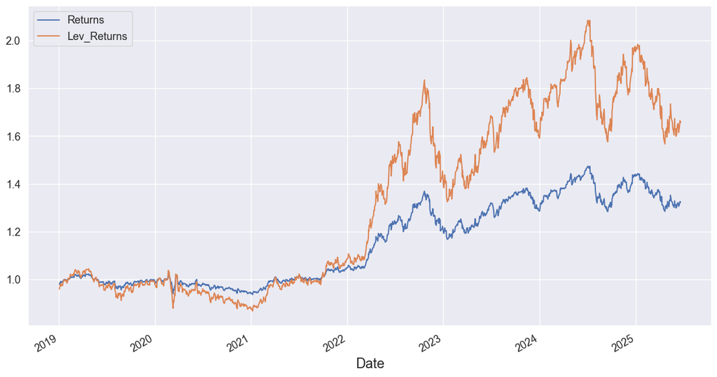

```python
usdjpy[["Returns", "Lev_Returns"]].add(1).cumprod().plot(figsize = (15, 8), fontsize = 13)
plt.legend(fontsize = 13)
plt.show()
```

```python
usdjpy.Simple_Ret.max()
```

```
0.0270487240619246
```

```python
usdjpy.Lev_Returns.max()
```

```
0.0540974481238492
```

```python
usdjpy.Simple_Ret.min()
```

```
-0.03724951281473232
```

```python
usdjpy.Lev_Returns.min()
```

```
-0.0744990256294646
```

**What happens when leverage greater than...?**

```python
-1 / usdjpy.Simple_Ret.min()
```

```
26.845988697186296
```

1. With Leverage you can (theoretically) **lose more than the initial Margin** (in practice: margin call / margin closeout before)
2. Even for (highly) profitable instruments: **"The more leverage the better" does not hold**.
3. It´s a two edged (**non-symmetrical**) sword: **Leverage amplifies losses more than it amplifies gains**.

```python
!jupyter nbconvert Financial.ipynb --to html --embed-imagesxxo html
```

```
[NbConvertApp] Converting notebook Financial.ipynb to html
[NbConvertApp] WARNING | Alternative text is missing on 15 image(s).
[NbConvertApp] Writing 1885205 bytes to Financial.html
```